# 1.0-bk-machine-learning-new

ML Group Project Part 3 : JBK

We are using DOLLAR BARS for this Analysis.

```python
import pandas as pd
import matplotlib.pyplot as plt
import matplotlib.dates as mdates
import matplotlib.gridspec as gridspec
import numpy as np
import scipy.stats as stats
import statsmodels.api as sm
import missingno as mn
import seaborn as sns
from statsmodels.graphics.tsaplots import plot_acf
import datetime as dt
from pprint import pprint
import time
import talib
import warnings
from multiprocessing import cpu_count
from sklearn.ensemble import RandomForestRegressor
from sklearn.ensemble import RandomForestClassifier
from sklearn.model_selection import train_test_split
from sklearn.metrics import roc_curve, roc_auc_score, auc, accuracy_score, classification_report, confusion_matrix
from sklearn.tree import export_graphviz
import pydot
%matplotlib inline

warnings.filterwarnings('ignore')
RANDOM_STATE = 42
```

```python
#
# Import private functions created by the team which we moved out
# into PEP8 compliant python files, in order to not clutter
# the notebook.
#
import os
import sys
module_path = os.path.abspath(os.path.join('../modules'))
# print(module_path)
# print(sys.path)
if module_path not in sys.path:
    sys.path.append(module_path)

import bars_tools
import deprado
import technical_analysis
import plot_roc_curve
```

Since Parts 1 and 2, most of our functions have been moved to modules and are imported above:

```
* bars_tools:

    def create_bars(df, col, m, bartype="tick"):`
    def create_bar_df(df, col, m, bartype="tick"):
    def calc_ohlc(reference_col, subset_df, bartype="tick"):

* deprado:

    def getDailyVolatility(close, span0=100):
    def applyPtSlOnT1(close, events, ptSl, molecule):
    def getEvents(close,
    def getTEvents(gRaw, h):
    def addVerticalBarrier(tEvents, close, numDays=1):
    def linParts(numAtoms, numThreads):
    def nestedParts(numAtoms, numThreads, upperTriang=False):
    def processJobs_(jobs):
    def mpPandasObj(func, pdObj, numThreads=24, mpBatches=1, linMols=True,
    def reportProgress(jobNum, numJobs, time0, task):
    def processJobs(jobs, task=None, numThreads=24):
    def expandCall(kargs):
    def getBins(events, close):
    def dropLabels(events, minPct=.05):

* technical_analysis:

    def get_ma_cross_up(df):
    def get_ma_cross_down(df):
    def rel_strength_indicator(close, n=14):
    def get_up_rsi(df):
    def get_down_rsi(df):
    def get_aroon_cross_up(df):
    def get_aroon_cross_down(df):

* plot_roc_curve:

    def plot_roc_curve(fprs, tprs):
```

Read 1 min BTC (Bitcoin) data from file

```python
df = (pd.read_csv("../data/raw/coinbaseUSD_1-min_data_2014-12-01_to_2018-11-11.csv",
      usecols=['Timestamp', 'Weighted_Price', 'Volume_(BTC)'])
      .rename(columns={'Volume_(BTC)': 'Volume', 'Volume_(Currency)': 'Dollars', 'Timestamp': 'TS', 'Weighted_Price': 'Price'})
      .assign(Timestamp=lambda df: (pd.to_datetime(df['TS'], unit='s')))
      .assign(DollarVol=lambda df: df['Price']*df['Volume'])
      .set_index('Timestamp')
      .drop('TS', axis=1))
```

The data is missing a lot of mins early on at the beginning, presumably it wasn't traded frequently enough then. So we remove data before February 2015, fill forward any remaining NaN values, and add a cumulative volume column, for extra information.

```python
from_ts = '2014-12-01 05:33:00'
to_ts = '2015-02-01 00:00:00'
df = df[(df.index < from_ts) | (df.index > to_ts)]

df[df.columns.values] = df[df.columns.values].ffill()
df['CumVol'] = df['Volume'].cumsum()
```

```python
print(df.DollarVol.min())
print(df.DollarVol.max())
```

```
2.6417e-06
19970764.734331846
```

```python
df.head()
```

| Timestamp | Volume | Price | DollarVol | CumVol |
| --- | --- | --- | --- | --- |
| 2015-02-01 00:01:00 | 4.80312 | 218.694363 | 1050.415266 | 4.80312 |
| 2015-02-01 00:02:00 | 4.87680 | 218.748834 | 1066.794313 | 9.67992 |
| 2015-02-01 00:03:00 | 7.26810 | 218.717917 | 1589.663689 | 16.94802 |
| 2015-02-01 00:04:00 | 0.25390 | 218.683698 | 55.523791 | 17.20192 |
| 2015-02-01 00:05:00 | 0.03000 | 218.520000 | 6.555600 | 17.23192 |

```python
df.shape
```

```
(1985760, 4)
```

Save processed/cleaned data.

```python
df.to_csv("../data/processed/coinbase_btc_min_data_processed.csv", sep=',', encoding='utf-8')
```

Examine the time series with a plot.

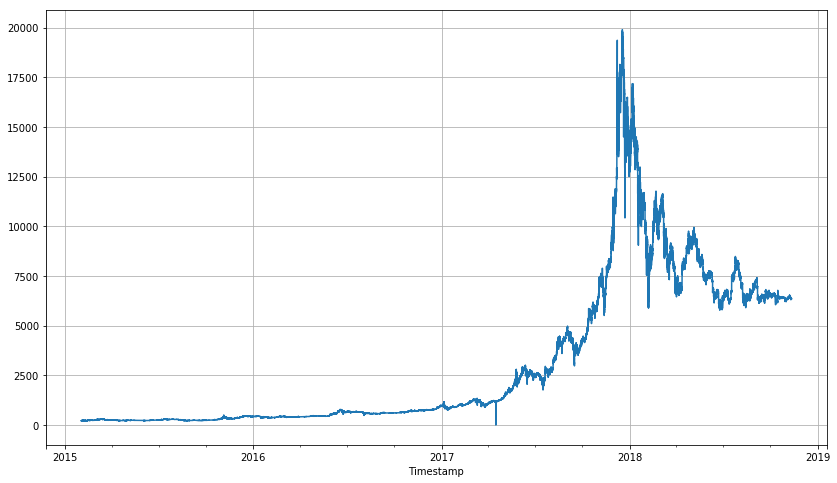

```python
df['Price'].plot(kind='line', figsize=(14,8), grid=True)
```

We needed more bars to work with than we had in Parts 1 and 2, really. So here we are using Bitcoin data from Kaggle that originally comes in a file of >2m minute bars. We're going to create Dollar Bars from it. This uses functions from our create_bars module in the modules folder. We have moved many functions out of the notebook to avoid cluttering it unnecessarily, but these functions play an essential and important role.

```python
threshold_amount_of_dollars =  300 # Arbitraily choose threshold
print(f'Dollar threshold value: {threshold_amount_of_dollars:,}')
dollar_bar_df = bars_tools.create_bar_df(df, 'DollarVol', threshold_amount_of_dollars, "dollar")
# Examine the DF
dollar_bar_df.head()
```

```
Dollar threshold value: 300
```

| Timestamp | Volume | Price | DollarVol | CumVol |
| --- | --- | --- | --- | --- |
| 2015-02-01 00:01:00 | 4.80312 | 218.694363 | 1050.415266 | 4.80312 |
| 2015-02-01 00:02:00 | 4.87680 | 218.748834 | 1066.794313 | 9.67992 |
| 2015-02-01 00:03:00 | 7.26810 | 218.717917 | 1589.663689 | 16.94802 |
| 2015-02-01 00:07:00 | 1.19840 | 218.520083 | 261.874468 | 18.51032 |
| 2015-02-01 00:08:00 | 1.49210 | 218.515707 | 326.047287 | 20.00242 |

```python
dollar_bar_df.shape
```

```
(1677763, 4)
```

Computing ohlc dollar bars with a threshold of $300 takes about 12 mins.

```python
dollar_bars_ohlc = bars_tools.calc_ohlc(df.DollarVol, dollar_bar_df, "dollar")
dollar_bars_ohlc.index = pd.to_datetime(dollar_bars_ohlc['End'], format='%Y-%m-%d %H:%M:%S.%f')
dollar_bars_ohlc.set_index('End', inplace=True)
dollar_bars_ohlc.head()
```

| End | Start | Open | High | Low | Close | ClosePrice |
| --- | --- | --- | --- | --- | --- | --- |
| 2015-02-01 00:02:00 | 2015-02-01 00:01:00 | 1050.415266 | 1066.794313 | 1050.415266 | 1066.794313 | 218.748834 |
| 2015-02-01 00:03:00 | 2015-02-01 00:02:00 | 1066.794313 | 1589.663689 | 1066.794313 | 1589.663689 | 218.717917 |
| 2015-02-01 00:07:00 | 2015-02-01 00:03:00 | 1589.663689 | 1589.663689 | 6.555600 | 261.874468 | 218.520083 |
| 2015-02-01 00:08:00 | 2015-02-01 00:07:00 | 261.874468 | 326.047287 | 261.874468 | 326.047287 | 218.515707 |
| 2015-02-01 00:09:00 | 2015-02-01 00:08:00 | 326.047287 | 2943.389665 | 326.047287 | 2943.389665 | 218.392852 |

```python
dollar_bars_ohlc.shape
```

```
(1677762, 6)
```

```python
dollar_bars_ohlc.to_csv("../data/processed/dollar_bars_ohlc.csv", sep=',', encoding='utf-8')
```

Compute log returns for dollar bars

```python
def log_returns(s):
    returns_array = np.diff(np.log(s))
    return (pd.Series(returns_array, index=s.index[1:]))
```

```python
dollar_bar_returns = log_returns(dollar_bars_ohlc.ClosePrice)
dollar_bar_returns = np.float16(dollar_bar_returns)
dollar_bar_returns
```

```
array([-1.414e-04, -9.050e-04, -2.003e-05, ..., -1.192e-07,  5.960e-08,
       -2.384e-07], dtype=float16)
```

Plot the distribution of Dollar Bar returns

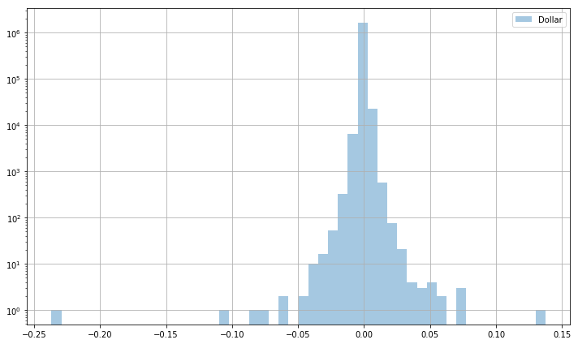

```python
bar_types = 'Dollar'
bar_returns = dollar_bar_returns

f,ax=plt.subplots(figsize=(10,6))

g = sns.distplot(bar_returns, ax=ax, kde=False, label=bar_types)
g.set(yscale='log')
ax.legend()
plt.grid()
plt.tight_layout()
```

With so much data, computing autocorrelation takes a long time. We are going to skip it especially as it doesn't return anything we can use effectively.

```python
#fig, ax = plt.subplots(figsize=(16,4))
#plot_acf(bar_returns[-100000:], ax, lags=20)
#ax.set_title('Autocorrelation (%s Bars)' % bar_types)
#plt.grid()
```

# DAILY VOLATILITY

```python
n_dollar_bars = dollar_bars_ohlc['Close'].resample('W').count()
n_dollar_bars.head()
```

```
End
2015-02-01     919
2015-02-08    5760
2015-02-15    7065
2015-02-22    7326
2015-03-01    7190
Freq: W-SUN, Name: Close, dtype: int64
```

Count the number of weeks

```python
n_dollar_bars.shape
```

```
(198,)
```

```python
bar_counts_df = pd.concat([n_dollar_bars], axis=1)
bar_counts_df.columns = ['DollarVol']
bar_counts_df[1:].DollarVol.sum() / (198 * 7)
```

```
1209.8434343434344
```

Use 1209 bars for span0 to approximate daily volatility

```python
close = dollar_bars_ohlc.ClosePrice.copy()
dailyVolatility = pd.DataFrame(deprado.getDailyVolatility(close, span0=1209))
dailyVolatility.dropna(inplace=True)
dailyVolatility.head(5)
```

| End | dailyVolatility |
| --- | --- |
| 2015-02-02 00:08:00 | 0.000665 |
| 2015-02-02 00:09:00 | 0.000549 |
| 2015-02-02 00:10:00 | 0.005090 |
| 2015-02-02 00:12:00 | 0.004421 |
| 2015-02-02 00:14:00 | 0.005793 |

Plot the Daily Volatility of the **Close Price** of Dollar Bars, and the Mean Daily Volatility. Then run the CUSUM Filter against the Dollar Bar Closes with threshold equal to **40%** of the Mean of Daily Volatility as we do not really expect to capture all of the mean daily vol.

```
0.020613545097033652
```

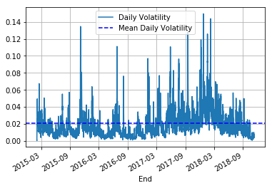

```python
f,ax=plt.subplots()
dailyVolatility.plot(ax=ax)
ax.axhline(dailyVolatility.dailyVolatility.mean(),ls='--', color='b', label="Mean Volatility")
ax.legend(["Daily Volatility", "Mean Daily Volatility"])
ax.grid()
print(dailyVolatility.dailyVolatility.mean())
```

```python
minRet = dailyVolatility.dailyVolatility.mean() * 0.4
minRet
```

```
0.008245418038813462
```

Get the timestamps where the Close price of the Dollar Bar exceeds the threshold of mean Daily Volatility. These will be our threshold events for vertical barriers.

```python
thresholdEvents = deprado.getTEvents(close,h=minRet)
thresholdEvents
```

```
DatetimeIndex(['2015-02-01 00:49:00', '2015-02-01 00:55:00',
               '2015-02-01 01:32:00', '2015-02-01 02:27:00',
               '2015-02-01 02:52:00', '2015-02-01 03:30:00',
               '2015-02-01 03:56:00', '2015-02-01 04:30:00',
               '2015-02-01 05:08:00', '2015-02-01 05:35:00',
               ...
               '2018-11-04 18:26:00', '2018-11-05 04:01:00',
               '2018-11-06 09:56:00', '2018-11-06 11:56:00',
               '2018-11-06 23:55:00', '2018-11-07 00:25:00',
               '2018-11-08 02:41:00', '2018-11-08 16:02:00',
               '2018-11-09 09:35:00', '2018-11-10 12:49:00'],
              dtype='datetime64[ns]', length=32657, freq=None)
```

```python
t1 = deprado.addVerticalBarrier(thresholdEvents, close)
t1.head()
```

```
2015-02-01 00:49:00   2015-02-02 00:49:00
2015-02-01 00:55:00   2015-02-02 00:55:00
2015-02-01 01:32:00   2015-02-02 01:35:00
2015-02-01 02:27:00   2015-02-02 02:27:00
2015-02-01 02:52:00   2015-02-02 02:58:00
Name: End, dtype: datetime64[ns]
```

**NOTE:** ptS1 of [1, 2] describes the horizontal barrier - in this particular case the profit-taking barrier is half x the stop-loss barrier

- trgt: The unit width of the horizontal barriers.
- ptSl: A list of two non-negative float values:
  - ptSl[0]: The factor that multiplies trgt to set the width of the upper barrier. If 0, there will not be an upper barrier.
  - ptSl[1]: The factor that multiplies trgt to set the width of the lower barrier. If 0, there will not be a lower barrier.

```python
# create target series
ptSl = [1,2]
target=dailyVolatility.dailyVolatility

# Run in single-threaded mode on Windows
import platform
if platform.system() == "Windows":
    cpus = 1
else:
    cpus = cpu_count() - 1

events = deprado.getEvents(close,thresholdEvents,ptSl,target,minRet,cpus,t1=t1)

events.head()
```

```
2018-11-19 20:13:50.300516 100.0% applyPtSlOnT1 done after 0.27 minutes. Remaining 0.0 minutes..
```

|  | t1 | trgt |
| --- | --- | --- |
| 2015-02-02 07:18:00 | 2015-02-02 12:13:00 | 0.011905 |
| 2015-02-02 08:09:00 | 2015-02-02 12:03:00 | 0.011918 |
| 2015-02-02 08:23:00 | 2015-02-02 13:06:00 | 0.012045 |
| 2015-02-02 08:45:00 | 2015-02-02 12:03:00 | 0.011872 |
| 2015-02-02 11:12:00 | 2015-02-02 13:06:00 | 0.011802 |

This groups the returns into 1.0 or -1.0 bins that made the minRet threshold (either direction), 1.0 for "went up" (positive return) and -1.0 for "went down" (negative return)

```python
labels = deprado.getBins(events, close)
labels.head(10)
```

|  | ret | bin |
| --- | --- | --- |
| 2015-02-02 07:18:00 | 0.012494 | 1.0 |
| 2015-02-02 08:09:00 | 0.012793 | 1.0 |
| 2015-02-02 08:23:00 | 0.013070 | 1.0 |
| 2015-02-02 08:45:00 | 0.012790 | 1.0 |
| 2015-02-02 11:12:00 | 0.012129 | 1.0 |
| 2015-02-02 12:02:00 | 0.013572 | 1.0 |
| 2015-02-02 12:03:00 | -0.013044 | -1.0 |
| 2015-02-02 13:09:00 | -0.021805 | -1.0 |
| 2015-02-02 13:17:00 | -0.015466 | -1.0 |
| 2015-02-02 13:26:00 | 0.025314 | 1.0 |

Count the labels of each type

```python
labels.bin.value_counts()
```

```
 1.0    16815
-1.0    14687
Name: bin, dtype: int64
```

dropLabels (none to clean up, apparently)

```python
clean_labels = deprado.dropLabels(labels)
clean_labels.bin.value_counts()
```

```
 1.0    16815
-1.0    14687
Name: bin, dtype: int64
```

Let's look at some Technical Analysis methods we might use: MA Crossover, the RSI Indicator and the Aroon Indicator.

# MA CROSSOVER

A crossover is the most basic type of signal and is favored among many traders because it removes all emotion. The most basic type of crossover is when the price of an asset moves from one side of a moving average and closes on the other. Price crossovers are used by traders to identify shifts in momentum and can be used as a basic entry or exit strategy. This is often implemented with a fast (short-term) moving average and a "slow" (long =-term moving average). A cross of the fast MA below the slow MA from above can signal the beginning of a downtrend and would likely be used by traders as a signal to close out any existing long positions and possibly go short. Conversely, a close of the fast MA above the slow MA from below may suggest the beginning of a new uptrend and signal going long.

Now, let's apply the above labeling/triple-barrier method to some meta-labelling of a specific feature like MA crossover. The idea is that once we have this working we can extend it to other technical indicators such as RSI, Bollinger Bands, etc.

Based on the Serial Correlation example in Part 1 (Notebook 1.0-bk-data-exploration_of_bar_types.ipynb), we found that Volume Bars have the lowest Serial Correlation and also have positive peaks at 3 and 6 lag periods.

With this new data we have switched to Dollar Bars for reasons mentioned earlier. With larger datasets the computation of autocorrelation is intensive and lengthy, so we are going to use 8/21 period MA crossover for no reason other than these are Fibonacci numbers.

Sources:

```
* https://www.investopedia.com/university/movingaverage/movingaverages4.asp
```

```python
dollar_bars_ohlc['fast'] = dollar_bars_ohlc.rolling(window=8)['ClosePrice'].mean()
dollar_bars_ohlc['slow'] = dollar_bars_ohlc.rolling(window=21)['ClosePrice'].mean()
dollar_bars_ohlc.index = pd.to_datetime(dollar_bars_ohlc.index)
dollar_bars_ohlc.head(16)
```

| End | Start | Open | High | Low | Close | ClosePrice | fast | slow |
| --- | --- | --- | --- | --- | --- | --- | --- | --- |
| 2015-02-01 00:02:00 | 2015-02-01 00:01:00 | 1050.415266 | 1066.794313 | 1050.415266 | 1066.794313 | 218.748834 | NaN | NaN |
| 2015-02-01 00:03:00 | 2015-02-01 00:02:00 | 1066.794313 | 1589.663689 | 1066.794313 | 1589.663689 | 218.717917 | NaN | NaN |
| 2015-02-01 00:07:00 | 2015-02-01 00:03:00 | 1589.663689 | 1589.663689 | 6.555600 | 261.874468 | 218.520083 | NaN | NaN |
| 2015-02-01 00:08:00 | 2015-02-01 00:07:00 | 261.874468 | 326.047287 | 261.874468 | 326.047287 | 218.515707 | NaN | NaN |
| 2015-02-01 00:09:00 | 2015-02-01 00:08:00 | 326.047287 | 2943.389665 | 326.047287 | 2943.389665 | 218.392852 | NaN | NaN |
| 2015-02-01 00:10:00 | 2015-02-01 00:09:00 | 2943.389665 | 2943.389665 | 1091.849900 | 1091.849900 | 218.369980 | NaN | NaN |
| 2015-02-01 00:14:00 | 2015-02-01 00:10:00 | 1091.849900 | 1167.282966 | 4.148350 | 1167.282966 | 218.240842 | NaN | NaN |
| 2015-02-01 00:15:00 | 2015-02-01 00:14:00 | 1167.282966 | 2337.863647 | 1167.282966 | 2337.863647 | 218.102606 | 218.451103 | NaN |
| 2015-02-01 00:20:00 | 2015-02-01 00:15:00 | 2337.863647 | 2337.863647 | 3.667172 | 1083.190551 | 218.768919 | 218.453613 | NaN |
| 2015-02-01 00:22:00 | 2015-02-01 00:20:00 | 1083.190551 | 2940.875672 | 33.579196 | 2940.875672 | 218.649963 | 218.445119 | NaN |
| 2015-02-01 00:25:00 | 2015-02-01 00:22:00 | 2940.875672 | 2940.875672 | 2.186200 | 1658.250002 | 218.697218 | 218.467261 | NaN |
| 2015-02-01 00:26:00 | 2015-02-01 00:25:00 | 1658.250002 | 1658.250002 | 402.796032 | 402.796032 | 218.910054 | 218.516554 | NaN |
| 2015-02-01 00:27:00 | 2015-02-01 00:26:00 | 402.796032 | 822.980371 | 402.796032 | 822.980371 | 218.998966 | 218.592319 | NaN |
| 2015-02-01 00:28:00 | 2015-02-01 00:27:00 | 822.980371 | 1052.648137 | 822.980371 | 1052.648137 | 219.052682 | 218.677656 | NaN |
| 2015-02-01 00:29:00 | 2015-02-01 00:28:00 | 1052.648137 | 4526.095055 | 1052.648137 | 4526.095055 | 219.336434 | 218.814605 | NaN |
| 2015-02-01 00:30:00 | 2015-02-01 00:29:00 | 4526.095055 | 4526.095055 | 1489.548450 | 1489.548450 | 219.370620 | 218.973107 | NaN |

Using functions from our technical_analysis module, find MA up and down crosses.

```python
up = technical_analysis.get_ma_cross_up(dollar_bars_ohlc)
down = technical_analysis.get_ma_cross_down(dollar_bars_ohlc)
```

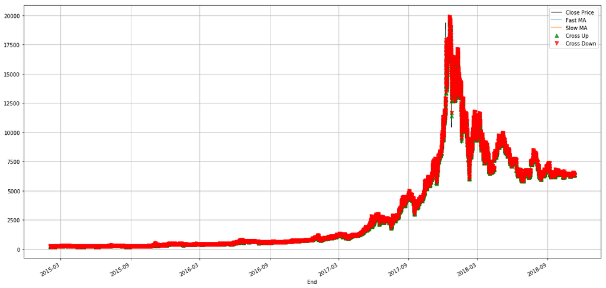

```python
f, ax = plt.subplots(figsize=(20,10))

dollar_bars_ohlc['ClosePrice'].plot(ax=ax, c='black', linewidth=1.25)
dollar_bars_ohlc['fast'].plot(ax=ax, alpha=.5)
dollar_bars_ohlc['slow'].plot(ax=ax, alpha=.5)
up.plot(ax=ax,ls='',marker='^', markersize=7,
                     alpha=0.75, label='upcross', color='g')
down.plot(ax=ax,ls='',marker='v', markersize=7,
                       alpha=0.75, label='downcross', color='r')
ax.grid()
ax.legend(["Close Price", "Fast MA", "Slow MA", "Cross Up", "Cross Down"])
```

With so much data, there are many short-term signals and they sort of meld together! One thing to consider might be crossovers of slower MAs.

Meta-labeling of ptS1 = [1,2] and t1 (1)

```python
side_up = pd.Series(1, index=up.index)
side_down = pd.Series(-1, index=down.index)
side = pd.concat([side_up,side_down]).sort_index()
side.head(20)
```

```
End
2015-02-01 00:49:00   -1
2015-02-01 01:07:00    1
2015-02-01 02:08:00   -1
2015-02-01 02:47:00    1
2015-02-01 03:12:00   -1
2015-02-01 03:30:00    1
2015-02-01 04:01:00   -1
2015-02-01 04:14:00    1
2015-02-01 04:30:00   -1
2015-02-01 04:52:00    1
2015-02-01 05:02:00   -1
2015-02-01 05:20:00    1
2015-02-01 05:31:00   -1
2015-02-01 05:54:00    1
2015-02-01 07:47:00   -1
2015-02-01 10:47:00    1
2015-02-01 11:10:00   -1
2015-02-01 11:54:00    1
2015-02-01 12:47:00   -1
2015-02-01 13:07:00    1
dtype: int64
```

Earlier, we set minRet value (0.4x daily volatility).

```python
minRetMA = minRet
ptSl=[1,2]
ma_events = deprado.getEvents(close,thresholdEvents,ptSl,target,minRetMA,cpus,t1=t1,side=side)
ma_events.head()
```

```
2018-11-19 20:17:01.087590 100.0% applyPtSlOnT1 done after 0.29 minutes. Remaining 0.0 minutes..
```

|  | side | t1 | trgt |
| --- | --- | --- | --- |
| 2015-02-02 07:18:00 | 1.0 | 2015-02-02 12:13:00 | 0.011905 |
| 2015-02-02 08:09:00 | NaN | 2015-02-03 08:10:00 | 0.011918 |
| 2015-02-02 08:23:00 | NaN | 2015-02-03 08:23:00 | 0.012045 |
| 2015-02-02 08:45:00 | NaN | 2015-02-03 08:45:00 | 0.011872 |
| 2015-02-02 11:12:00 | NaN | 2015-02-03 11:12:00 | 0.011802 |

```python
ma_events.shape
```

```
(31502, 3)
```

```python
ma_events.side.value_counts()
```

```
-1.0    1025
 1.0     975
Name: side, dtype: int64
```

This indicates 1025 short trades, 975 long trades

```python
ma_side = ma_events.dropna().side
ma_side.head()
```

```
2015-02-02 07:18:00    1.0
2015-02-02 14:59:00   -1.0
2015-02-03 03:38:00   -1.0
2015-02-03 08:41:00    1.0
2015-02-03 09:34:00   -1.0
Name: side, dtype: float64
```

```python
ma_bins = deprado.getBins(ma_events,close).dropna()
ma_bins.head()
```

|  | ret | bin |
| --- | --- | --- |
| 2015-02-02 07:18:00 | 0.012494 | 1.0 |
| 2015-02-02 14:59:00 | 0.015147 | 1.0 |
| 2015-02-03 03:38:00 | 0.025859 | 1.0 |
| 2015-02-03 08:41:00 | -0.046545 | 0.0 |
| 2015-02-03 09:34:00 | 0.029690 | 1.0 |

This saves all successful trades (bin value {1}) and unsuccessful trades (bin value {0}), whether long {1} or short {-1}

Below, we perform an asof merge to get the side onto the return and bin information above. This is similar to a left-join except that we match on nearest key rather than equal keys.

Both DataFrames must be sorted by the key.

For each row in the left DataFrame:

```
* A “backward” search selects the last row in the right DataFrame whose ‘on’ key is less than or equal to the left’s key.
* A “forward” search selects the first row in the right DataFrame whose ‘on’ key is greater than or equal to the left’s key.
* A “nearest” search selects the row in the right DataFrame whose ‘on’ key is closest in absolute distance to the left’s key.
```

```python
Xx = pd.merge_asof(ma_bins, side.to_frame().rename(columns={0:'side'}),
                   left_index=True, right_index=True, direction='forward')

Xx.head()
```

|  | ret | bin | side |
| --- | --- | --- | --- |
| 2015-02-02 07:18:00 | 0.012494 | 1.0 | 1 |
| 2015-02-02 14:59:00 | 0.015147 | 1.0 | -1 |
| 2015-02-03 03:38:00 | 0.025859 | 1.0 | -1 |
| 2015-02-03 08:41:00 | -0.046545 | 0.0 | 1 |
| 2015-02-03 09:34:00 | 0.029690 | 1.0 | -1 |

What is the explanation here? Consider the first row, "2015-02-02 07:18:00 0.012494 1.0 1" - this was trading on the buy side, {1} the return was positive and g.t. the minRet threshold, so it goes in bin {1}, i.e. successful trade. Consider the row "2015-02-03 08:41:00 -0.046545 0.0 1" - this was also trading on the buy side and the return was negative (not above the threshold), so it goes in bin {0}, i.e. labelled as a failed trade. This is how we wrangle the data into a format suitable for a binary classifier such as a random forest.

The model (crossing of ma 8/21) has determined the side to trade: {-1,1} (short and long). This is a general idea of engineering the feature according to de Prado's suggested methods. **We can now train a Random Forest classifier to decide whether to use this feature to trade or not, i.e. a decision {1,0}.** Here we plot the ROC (Receiver Operating Characteristic) curve.

An ROC curve (receiver operating characteristic curve) is a graph showing the performance of a classification model at all classification thresholds. This curve plots two parameters:

```
* True Positive Rate (synonym for recall)
* False Positive Rate
```

We also compute the AUC value, which is the area under the curve. AUC measures how true positive rate (recall) and false positive rate trade off. More importantly, AUC is not a function of threshold. It is an evaluation of the classifier as threshold varies over all possible values. It is in a sense a broader metric, testing the quality of the internal value that the classifier generates and then compares to a threshold. It is not testing the quality of a particular choice of threshold.

We perform similar metrics for the other technial features: RSI, Aroon.

Source:

```
* https://developers.google.com/machine-learning/crash-course/classification/roc-and-auc
```

**AUC, ROC, Accuracy for MA using Random Forest Classifier, deciding whether to trade or not {1,0}**

```
AUC: 0.509974687640865

Classification Report:
             precision    recall  f1-score   support

        0.0       0.00      0.00      0.00       241
        1.0       0.60      1.00      0.75       359

avg / total       0.36      0.60      0.45       600

Confusion Matrix:
[[  0 241]
 [  0 359]]

Accuracy Score:
0.5983333333333334

ROC Curve:
```

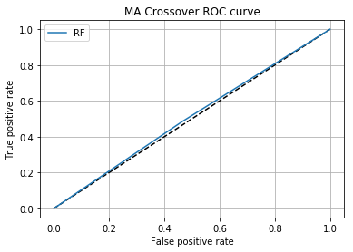

```python
X_ma = ma_side.values.reshape(-1,1)
y_ma = ma_bins.bin.values
X_ma_train, X_ma_test, y_ma_train, y_ma_test = train_test_split(X_ma, y_ma, test_size=0.3)

# Number of trees in the forest
n_estimator = 300
ma_random_forest = RandomForestClassifier(max_depth=2, n_estimators=n_estimator,
                            criterion='entropy', random_state=RANDOM_STATE)
ma_random_forest.fit(X_ma_train, y_ma_train)

# The random forest model by itself
y_ma_pred_random_forest = ma_random_forest.predict_proba(X_ma_test)[:, 1]
y_ma_pred = ma_random_forest.predict(X_ma_test)
fpr_ma_random_forest, tpr_ma_random_forest, _ = roc_curve(y_ma_test, y_ma_pred_random_forest)

print("AUC:", roc_auc_score(y_ma_test, y_ma_pred_random_forest))
print()
print("Classification Report:")
print(classification_report(y_ma_test, y_ma_pred))

print("Confusion Matrix:")
print(confusion_matrix(y_ma_test, y_ma_pred))
print()
print("Accuracy Score:")
print(accuracy_score(y_ma_test, y_ma_pred))
print()
print("ROC Curve:")
plt.figure(1)
plt.plot([0, 1], [0, 1], 'k--')
plt.plot(fpr_ma_random_forest, tpr_ma_random_forest, label='RF')
plt.xlabel('False positive rate')
plt.ylabel('True positive rate')
plt.title('MA Crossover ROC curve')
plt.legend(loc='best')
plt.grid()
plt.show()
```

**NOTE:** We are simply predicting trade or no trade here, which is why the confusion matrix only shows one column.

# RSI

Create a function for computing 14-period RSI. The Relative Strength Index - RSI - is a momentum indicator that measures the magnitude of recent price changes to analyze overbought or oversold conditions. It is primarily used to attempt to *identify* overbought or oversold conditions in the trading of an asset. Reasoning behind this identification: the RSI going below 30 indicates an oversold condition, and so a move back above 30 can be a signal to buy. Conversely, RSI above 70 indicates an overbought condition and a move back below 70 can be a signal to sell.

If the last close is the same as the previous, both U and D are zero. The average U and D are calculated using an n-period smoothed or modified moving average (SMMA or MMA) which is an exponentially smoothed Moving Average with α = 1/period. Some commercial packages, like AIQ, use a standard exponential moving average (EMA) as the average instead of Wilder's SMMA. Here we use a simple MA, or a rolling mean.

Wilder originally formulated the calculation of the moving average as: newval = (prevval * (period - 1) + newdata) / period. This is fully equivalent to the aforementioned exponential smoothing. New data is simply divided by period which is equal to the alpha calculated value of 1/period. Previous average values are modified by (period -1)/period which in effect is period/period - 1/period and finally 1 - 1/period which is 1 - alpha.

The relative strength factor is then converted to a relative strength index between 0 and 100.

The smoothed moving averages should be appropriately initialized with a simple moving average using the first n values in the price series.

Sources:

```
* https://www.investopedia.com/terms/r/rsi.asp
```

Add RSI to the OHLC DataFrame for Dollar Bars

```python
dollar_bars_ohlc['RSI'] = technical_analysis.rel_strength_indicator(close)
dollar_bars_ohlc.head(20)
```

| End | Start | Open | High | Low | Close | ClosePrice | fast | slow | RSI |
| --- | --- | --- | --- | --- | --- | --- | --- | --- | --- |
| 2015-02-01 00:02:00 | 2015-02-01 00:01:00 | 1050.415266 | 1066.794313 | 1050.415266 | 1066.794313 | 218.748834 | NaN | NaN | NaN |
| 2015-02-01 00:03:00 | 2015-02-01 00:02:00 | 1066.794313 | 1589.663689 | 1066.794313 | 1589.663689 | 218.717917 | NaN | NaN | NaN |
| 2015-02-01 00:07:00 | 2015-02-01 00:03:00 | 1589.663689 | 1589.663689 | 6.555600 | 261.874468 | 218.520083 | NaN | NaN | NaN |
| 2015-02-01 00:08:00 | 2015-02-01 00:07:00 | 261.874468 | 326.047287 | 261.874468 | 326.047287 | 218.515707 | NaN | NaN | NaN |
| 2015-02-01 00:09:00 | 2015-02-01 00:08:00 | 326.047287 | 2943.389665 | 326.047287 | 2943.389665 | 218.392852 | NaN | NaN | NaN |
| 2015-02-01 00:10:00 | 2015-02-01 00:09:00 | 2943.389665 | 2943.389665 | 1091.849900 | 1091.849900 | 218.369980 | NaN | NaN | NaN |
| 2015-02-01 00:14:00 | 2015-02-01 00:10:00 | 1091.849900 | 1167.282966 | 4.148350 | 1167.282966 | 218.240842 | NaN | NaN | NaN |
| 2015-02-01 00:15:00 | 2015-02-01 00:14:00 | 1167.282966 | 2337.863647 | 1167.282966 | 2337.863647 | 218.102606 | 218.451103 | NaN | NaN |
| 2015-02-01 00:20:00 | 2015-02-01 00:15:00 | 2337.863647 | 2337.863647 | 3.667172 | 1083.190551 | 218.768919 | 218.453613 | NaN | NaN |
| 2015-02-01 00:22:00 | 2015-02-01 00:20:00 | 1083.190551 | 2940.875672 | 33.579196 | 2940.875672 | 218.649963 | 218.445119 | NaN | NaN |
| 2015-02-01 00:25:00 | 2015-02-01 00:22:00 | 2940.875672 | 2940.875672 | 2.186200 | 1658.250002 | 218.697218 | 218.467261 | NaN | NaN |
| 2015-02-01 00:26:00 | 2015-02-01 00:25:00 | 1658.250002 | 1658.250002 | 402.796032 | 402.796032 | 218.910054 | 218.516554 | NaN | NaN |
| 2015-02-01 00:27:00 | 2015-02-01 00:26:00 | 402.796032 | 822.980371 | 402.796032 | 822.980371 | 218.998966 | 218.592319 | NaN | NaN |
| 2015-02-01 00:28:00 | 2015-02-01 00:27:00 | 822.980371 | 1052.648137 | 822.980371 | 1052.648137 | 219.052682 | 218.677656 | NaN | NaN |
| 2015-02-01 00:29:00 | 2015-02-01 00:28:00 | 1052.648137 | 4526.095055 | 1052.648137 | 4526.095055 | 219.336434 | 218.814605 | NaN | 63.871790 |
| 2015-02-01 00:30:00 | 2015-02-01 00:29:00 | 4526.095055 | 4526.095055 | 1489.548450 | 1489.548450 | 219.370620 | 218.973107 | NaN | 65.384979 |
| 2015-02-01 00:31:00 | 2015-02-01 00:30:00 | 1489.548450 | 6402.083040 | 1489.548450 | 6402.083040 | 219.749123 | 219.095633 | NaN | 76.696111 |
| 2015-02-01 00:32:00 | 2015-02-01 00:31:00 | 6402.083040 | 6402.083040 | 3551.629610 | 3551.629610 | 219.358248 | 219.184168 | NaN | 65.669891 |
| 2015-02-01 00:33:00 | 2015-02-01 00:32:00 | 3551.629610 | 3551.629610 | 2838.018350 | 2838.018350 | 219.155279 | 219.241426 | NaN | 63.769584 |
| 2015-02-01 00:34:00 | 2015-02-01 00:33:00 | 2838.018350 | 2838.018350 | 2439.465974 | 2439.465974 | 218.500000 | 219.190169 | NaN | 51.911538 |

```python
rsiup = technical_analysis.get_up_rsi(dollar_bars_ohlc)
rsidown = technical_analysis.get_down_rsi(dollar_bars_ohlc)
```

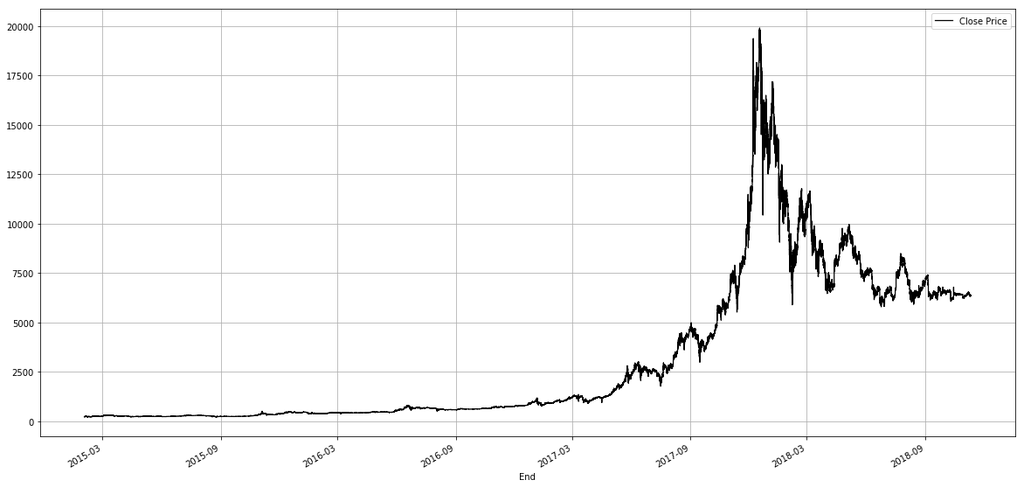

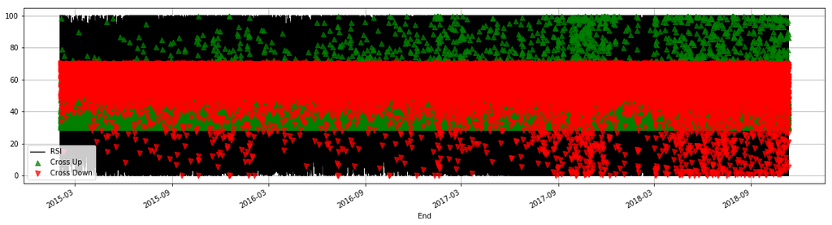

```python
f, ax1 = plt.subplots(figsize=(20,10))

dollar_bars_ohlc['ClosePrice'].plot(ax=ax1, c='black', linewidth=1.25)
ax1.grid()
ax1.legend(["Close Price"])

f, ax2 = plt.subplots(figsize=(20,5))
dollar_bars_ohlc['RSI'].plot(ax=ax2, c='black', linewidth=1.25)
rsiup.plot(ax=ax2,ls='',marker='^', markersize=7,
                     alpha=0.75, label='upcross', color='g')
rsidown.plot(ax=ax2,ls='',marker='v', markersize=7,
                       alpha=0.75, label='downcross', color='r')
ax2.grid()
ax2.legend(["RSI", "Cross Up", "Cross Down"])
```

With so much data, there are many short-term signals that meld together and some very strong moves towards the end of the dataset (more recently)! One thing to consider might be crossovers of a slower RSI, > 14 days.

Perform the same meta-labeling of ptS1 = [1,2] and t1 (1) on RSI as we did for MA Crossover

```python
side_up_rsi = pd.Series(1, index=rsiup.index)
side_down_rsi = pd.Series(-1, index=rsidown.index)
side_rsi = pd.concat([side_up_rsi,side_down_rsi]).sort_index()
side_rsi.head()
```

```
End
2015-02-01 00:30:00   -1
2015-02-01 00:48:00    1
2015-02-01 00:53:00    1
2015-02-01 01:12:00   -1
2015-02-01 01:15:00   -1
dtype: int64
```

```python
minRetRSI = minRet
ptSl=[1,2]
rsi_events = deprado.getEvents(close,thresholdEvents,ptSl,target,minRetRSI,cpus,t1=t1,side=side_rsi)
rsi_events.head()
```

```
2018-11-19 20:23:20.620920 100.0% applyPtSlOnT1 done after 0.3 minutes. Remaining 0.0 minutes.s.
```

|  | side | t1 | trgt |
| --- | --- | --- | --- |
| 2015-02-02 07:18:00 | NaN | 2015-02-03 07:18:00 | 0.011905 |
| 2015-02-02 08:09:00 | NaN | 2015-02-03 08:10:00 | 0.011918 |
| 2015-02-02 08:23:00 | NaN | 2015-02-03 08:23:00 | 0.012045 |
| 2015-02-02 08:45:00 | NaN | 2015-02-03 08:45:00 | 0.011872 |
| 2015-02-02 11:12:00 | NaN | 2015-02-03 11:12:00 | 0.011802 |

```python
rsi_events.shape
```

```
(31502, 3)
```

There is a bit more information with this BTC price data.

```python
rsi_events.side.value_counts()
```

```
-1.0    1005
 1.0    1004
Name: side, dtype: int64
```

Very even long/short distribution with RSI (1004/1005)

```python
rsi_side = rsi_events.dropna().side
rsi_side.head()
```

```
2015-02-02 16:20:00   -1.0
2015-02-02 17:04:00   -1.0
2015-02-03 15:48:00    1.0
2015-02-03 20:55:00   -1.0
2015-02-04 00:10:00   -1.0
Name: side, dtype: float64
```

```python
rsi_bins = deprado.getBins(rsi_events,close).dropna()
rsi_bins.head()
```

|  | ret | bin |
| --- | --- | --- |
| 2015-02-02 16:20:00 | -0.030811 | 0.0 |
| 2015-02-02 17:04:00 | -0.033687 | 0.0 |
| 2015-02-03 15:48:00 | -0.045893 | 0.0 |
| 2015-02-03 20:55:00 | 0.028502 | 1.0 |
| 2015-02-04 00:10:00 | 0.033213 | 1.0 |

```python
rsi_bins.bin.value_counts()
```

```
1.0    1139
0.0     870
Name: bin, dtype: int64
```

asof merge as before

```python
rsi_Xx = pd.merge_asof(rsi_bins, side_rsi.to_frame().rename(columns={0:'side'}),
                   left_index=True, right_index=True, direction='forward')

rsi_Xx.head()
```

|  | ret | bin | side |
| --- | --- | --- | --- |
| 2015-02-02 16:20:00 | -0.030811 | 0.0 | -1 |
| 2015-02-02 17:04:00 | -0.033687 | 0.0 | -1 |
| 2015-02-03 15:48:00 | -0.045893 | 0.0 | 1 |
| 2015-02-03 20:55:00 | 0.028502 | 1.0 | -1 |
| 2015-02-04 00:10:00 | 0.033213 | 1.0 | -1 |

The model (crossing of RSI above 30 or below 70) has determined the side to trade: {-1,1}. This a general idea of engineering the feature according to de Prado's suggested methods. We can now train a Random Forest classifier to decide whether to use this feature to trade or not, i.e. a decision {1,0}. Here we plot the ROC (Receiver Operating Characteristic) curve.

**AUC, ROC, Accuracy for RSI using Random Forest Classifier**

```
AUC: 0.5535205535205535

Classification Report:
             precision    recall  f1-score   support

        0.0       0.00      0.00      0.00       252
        1.0       0.58      1.00      0.74       351

avg / total       0.34      0.58      0.43       603

Confusion Matrix:
[[  0 252]
 [  0 351]]

Accuracy Score:
0.582089552238806

ROC Curve:
```

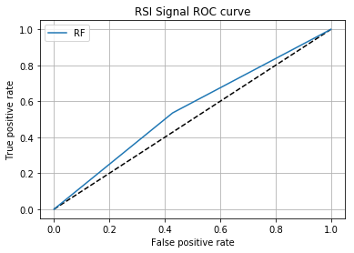

```python
X_rsi = rsi_side.values.reshape(-1,1)
y_rsi = rsi_bins.bin.values
X_rsi_train, X_rsi_test, y_rsi_train, y_rsi_test = train_test_split(X_rsi, y_rsi, test_size=0.3)

n_estimator = 300
rsi_random_forest = RandomForestClassifier(max_depth=2, n_estimators=n_estimator,
                            criterion='entropy', random_state=RANDOM_STATE)
rsi_random_forest.fit(X_rsi_train, y_rsi_train)

# The random forest model by itself
y_rsi_pred_random_forest = rsi_random_forest.predict_proba(X_rsi_test)[:, 1]

y_rsi_pred = rsi_random_forest.predict(X_rsi_test)
fpr_rsi_random_forest, tpr_rsi_random_forest, _ = roc_curve(y_rsi_test, y_rsi_pred_random_forest)

print("AUC:", roc_auc_score(y_rsi_test, y_rsi_pred_random_forest))
print()
print("Classification Report:")
print(classification_report(y_rsi_test, y_rsi_pred))
print("Confusion Matrix:")
print(confusion_matrix(y_rsi_test, y_rsi_pred))
print()
print("Accuracy Score:")
print(accuracy_score(y_rsi_test, y_rsi_pred))
print()
print("ROC Curve:")
plt.figure(1)
plt.plot([0, 1], [0, 1], 'k--')
plt.plot(fpr_rsi_random_forest, tpr_rsi_random_forest, label='RF')
plt.xlabel('False positive rate')
plt.ylabel('True positive rate')
plt.title('RSI Signal ROC curve')
plt.legend(loc='best')
plt.grid()
plt.show()
```

# AROON

The Aroon Indicator was developed by Tushar S. Chande. It is a technical indicator that is used to identify when trends are likely to change direction. In essence, the indicator measures the time it takes for the price to reach the highest and lowest points over a given timeframe as a percentage of total time. The indicator consists of the "Aroon up" line, which measures the strength of the uptrend, and the "Aroon down" line, which measures the strength of the downtrend.

The two component lines are calculated as follows:

```
* Aroon Up - ((N - Days Since N-day High) / N) x 100
* Aroon Down - ((N - Days Since N-day Low) / N) x 100
```

The N is the number of periods used for the indicator. By default, many traders use the Aroon indicator over 25 periods. To simplify calculation and save time, I have used the ta-lib implementation here. TA-lib is an excellent and somewhat under-rated Python library that all MSFE students should probably know about.

Source: https://www.investopedia.com/articles/trading/06/aroon.asp

```python
ardn, arup = talib.AROON(dollar_bars_ohlc['High'], dollar_bars_ohlc['Low'], 25)
dollar_bars_ohlc['AroonUp'] = arup.tolist()
dollar_bars_ohlc['AroonDn'] = ardn.tolist()
```

```python
dollar_bars_ohlc.head(30)
```

| End | Start | Open | High | Low | Close | ClosePrice | fast | slow | RSI | AroonUp | AroonDn |
| --- | --- | --- | --- | --- | --- | --- | --- | --- | --- | --- | --- |
| 2015-02-01 00:02:00 | 2015-02-01 00:01:00 | 1050.415266 | 1066.794313 | 1050.415266 | 1066.794313 | 218.748834 | NaN | NaN | NaN | NaN | NaN |
| 2015-02-01 00:03:00 | 2015-02-01 00:02:00 | 1066.794313 | 1589.663689 | 1066.794313 | 1589.663689 | 218.717917 | NaN | NaN | NaN | NaN | NaN |
| 2015-02-01 00:07:00 | 2015-02-01 00:03:00 | 1589.663689 | 1589.663689 | 6.555600 | 261.874468 | 218.520083 | NaN | NaN | NaN | NaN | NaN |
| 2015-02-01 00:08:00 | 2015-02-01 00:07:00 | 261.874468 | 326.047287 | 261.874468 | 326.047287 | 218.515707 | NaN | NaN | NaN | NaN | NaN |
| 2015-02-01 00:09:00 | 2015-02-01 00:08:00 | 326.047287 | 2943.389665 | 326.047287 | 2943.389665 | 218.392852 | NaN | NaN | NaN | NaN | NaN |
| 2015-02-01 00:10:00 | 2015-02-01 00:09:00 | 2943.389665 | 2943.389665 | 1091.849900 | 1091.849900 | 218.369980 | NaN | NaN | NaN | NaN | NaN |
| 2015-02-01 00:14:00 | 2015-02-01 00:10:00 | 1091.849900 | 1167.282966 | 4.148350 | 1167.282966 | 218.240842 | NaN | NaN | NaN | NaN | NaN |
| 2015-02-01 00:15:00 | 2015-02-01 00:14:00 | 1167.282966 | 2337.863647 | 1167.282966 | 2337.863647 | 218.102606 | 218.451103 | NaN | NaN | NaN | NaN |
| 2015-02-01 00:20:00 | 2015-02-01 00:15:00 | 2337.863647 | 2337.863647 | 3.667172 | 1083.190551 | 218.768919 | 218.453613 | NaN | NaN | NaN | NaN |
| 2015-02-01 00:22:00 | 2015-02-01 00:20:00 | 1083.190551 | 2940.875672 | 33.579196 | 2940.875672 | 218.649963 | 218.445119 | NaN | NaN | NaN | NaN |
| 2015-02-01 00:25:00 | 2015-02-01 00:22:00 | 2940.875672 | 2940.875672 | 2.186200 | 1658.250002 | 218.697218 | 218.467261 | NaN | NaN | NaN | NaN |
| 2015-02-01 00:26:00 | 2015-02-01 00:25:00 | 1658.250002 | 1658.250002 | 402.796032 | 402.796032 | 218.910054 | 218.516554 | NaN | NaN | NaN | NaN |
| 2015-02-01 00:27:00 | 2015-02-01 00:26:00 | 402.796032 | 822.980371 | 402.796032 | 822.980371 | 218.998966 | 218.592319 | NaN | NaN | NaN | NaN |
| 2015-02-01 00:28:00 | 2015-02-01 00:27:00 | 822.980371 | 1052.648137 | 822.980371 | 1052.648137 | 219.052682 | 218.677656 | NaN | NaN | NaN | NaN |
| 2015-02-01 00:29:00 | 2015-02-01 00:28:00 | 1052.648137 | 4526.095055 | 1052.648137 | 4526.095055 | 219.336434 | 218.814605 | NaN | 63.871790 | NaN | NaN |
| 2015-02-01 00:30:00 | 2015-02-01 00:29:00 | 4526.095055 | 4526.095055 | 1489.548450 | 1489.548450 | 219.370620 | 218.973107 | NaN | 65.384979 | NaN | NaN |
| 2015-02-01 00:31:00 | 2015-02-01 00:30:00 | 1489.548450 | 6402.083040 | 1489.548450 | 6402.083040 | 219.749123 | 219.095633 | NaN | 76.696111 | NaN | NaN |
| 2015-02-01 00:32:00 | 2015-02-01 00:31:00 | 6402.083040 | 6402.083040 | 3551.629610 | 3551.629610 | 219.358248 | 219.184168 | NaN | 65.669891 | NaN | NaN |
| 2015-02-01 00:33:00 | 2015-02-01 00:32:00 | 3551.629610 | 3551.629610 | 2838.018350 | 2838.018350 | 219.155279 | 219.241426 | NaN | 63.769584 | NaN | NaN |
| 2015-02-01 00:34:00 | 2015-02-01 00:33:00 | 2838.018350 | 2838.018350 | 2439.465974 | 2439.465974 | 218.500000 | 219.190169 | NaN | 51.911538 | NaN | NaN |
| 2015-02-01 00:35:00 | 2015-02-01 00:34:00 | 2439.465974 | 2439.465974 | 2439.465974 | 2439.465974 | 218.500000 | 219.127798 | 218.793158 | 53.960500 | NaN | NaN |
| 2015-02-01 00:40:00 | 2015-02-01 00:35:00 | 2439.465974 | 2439.465974 | 4.377600 | 563.668440 | 219.240933 | 219.151330 | 218.816592 | 64.690042 | NaN | NaN |
| 2015-02-01 00:41:00 | 2015-02-01 00:40:00 | 563.668440 | 1747.112860 | 563.668440 | 1747.112860 | 219.238657 | 219.139108 | 218.841389 | 57.315766 | NaN | NaN |
| 2015-02-01 00:42:00 | 2015-02-01 00:41:00 | 1747.112860 | 1747.112860 | 1490.804244 | 1490.804244 | 219.235886 | 219.122266 | 218.875475 | 59.467894 | NaN | NaN |
| 2015-02-01 00:44:00 | 2015-02-01 00:42:00 | 1490.804244 | 1569.813042 | 278.458875 | 1569.813042 | 219.247632 | 219.059579 | 218.910328 | 58.997354 | NaN | NaN |
| 2015-02-01 00:46:00 | 2015-02-01 00:44:00 | 1569.813042 | 1569.813042 | 221.291100 | 1496.798958 | 219.080085 | 219.024809 | 218.943054 | 52.821186 | 68.0 | 40.0 |
| 2015-02-01 00:47:00 | 2015-02-01 00:46:00 | 1496.798958 | 9160.345677 | 1496.798958 | 9160.345677 | 219.209432 | 219.031578 | 218.983028 | 53.445854 | 100.0 | 36.0 |
| 2015-02-01 00:48:00 | 2015-02-01 00:47:00 | 9160.345677 | 9160.345677 | 8493.679140 | 8493.679140 | 218.856234 | 219.076108 | 219.012332 | 47.070908 | 100.0 | 32.0 |
| 2015-02-01 00:49:00 | 2015-02-01 00:48:00 | 8493.679140 | 8493.679140 | 419.598554 | 419.598554 | 217.304991 | 218.926731 | 218.974350 | 28.018836 | 96.0 | 28.0 |
| 2015-02-01 00:50:00 | 2015-02-01 00:49:00 | 419.598554 | 6929.388435 | 419.598554 | 6929.388435 | 217.027978 | 218.650112 | 218.891448 | 25.917070 | 92.0 | 24.0 |

```python
arup = technical_analysis.get_aroon_cross_up(dollar_bars_ohlc)
ardown = technical_analysis.get_aroon_cross_down(dollar_bars_ohlc)
```

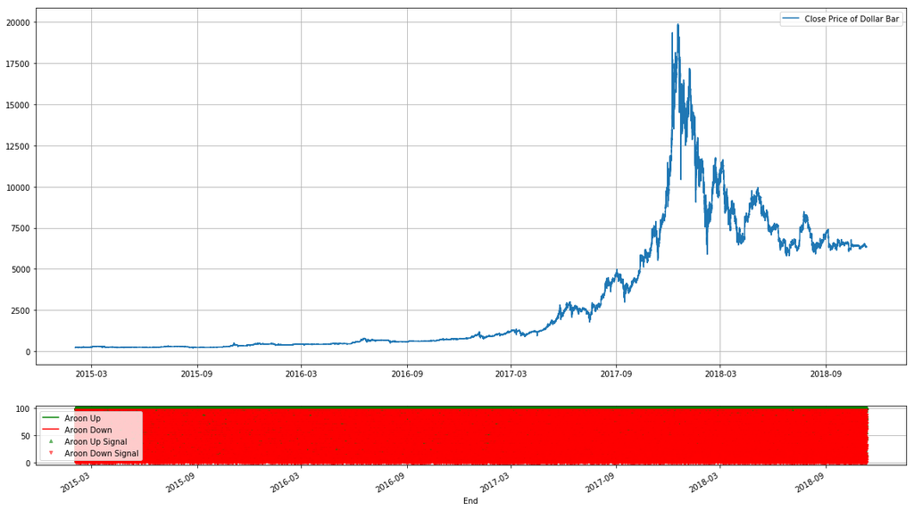

```python
fig = plt.figure(figsize=(20,12))
gs = gridspec.GridSpec(2, 1, height_ratios=[6,1])
ax0 = plt.subplot(gs[0])
ax1 = plt.subplot(gs[1])

ax0.plot(dollar_bars_ohlc['ClosePrice'])
ax0.grid()
ax0.legend(["Close Price of Dollar Bar"])
ax1.plot(dollar_bars_ohlc['AroonUp'], 'g')
ax1.plot(dollar_bars_ohlc['AroonDn'], 'r')
arup.plot(ax=ax1,ls='',marker='^', markersize=4,
                     alpha=0.5, label='upcross', color='g')
ardown.plot(ax=ax1,ls='',marker='v', markersize=4,
                       alpha=0.5, label='downcross', color='r')
ax1.grid()
ax1.legend(["Aroon Up", "Aroon Down", "Aroon Up Signal", "Aroon Down Signal"])
```

Once again there are many signals, given the volume of data.

```python
side_up_aroon = pd.Series(1, index=arup.index)
side_down_aroon = pd.Series(-1, index=ardown.index)
side_aroon = pd.concat([side_up_aroon,side_down_aroon]).sort_index()
side_aroon.head()
```

```
End
2015-02-01 01:13:00   -1
2015-02-01 01:26:00    1
2015-02-01 01:30:00   -1
2015-02-01 01:49:00    1
2015-02-01 02:41:00   -1
dtype: int64
```

```python
minRetAroon = minRet
ptSl=[1,2]
aroon_events = deprado.getEvents(close,thresholdEvents,ptSl,target,minRetAroon,cpus,t1=t1,side=side_aroon)
aroon_events.head()
```

```
2018-11-19 20:29:27.315212 100.0% applyPtSlOnT1 done after 0.3 minutes. Remaining 0.0 minutes.s.
```

|  | side | t1 | trgt |
| --- | --- | --- | --- |
| 2015-02-02 07:18:00 | NaN | 2015-02-03 07:18:00 | 0.011905 |
| 2015-02-02 08:09:00 | NaN | 2015-02-03 08:10:00 | 0.011918 |
| 2015-02-02 08:23:00 | NaN | 2015-02-03 08:23:00 | 0.012045 |
| 2015-02-02 08:45:00 | NaN | 2015-02-03 08:45:00 | 0.011872 |
| 2015-02-02 11:12:00 | NaN | 2015-02-03 11:12:00 | 0.011802 |

```python
aroon_events.shape
```

```
(31502, 3)
```

A lot more data than in Parts 1 and 2!

```python
aroon_events.side.value_counts()
```

```
 1.0    2311
-1.0     610
Name: side, dtype: int64
```

Aroon seems to generate almost 4x as many long trade signals as short trade signals.

```python
aroon_side = aroon_events.dropna().side
aroon_side.head()
```

```
2015-02-02 14:56:00    1.0
2015-02-02 15:32:00    1.0
2015-02-02 19:59:00    1.0
2015-02-03 07:24:00    1.0
2015-02-03 18:02:00   -1.0
Name: side, dtype: float64
```

```python
aroon_bins = deprado.getBins(aroon_events, close).dropna()
aroon_bins.head()
```

|  | ret | bin |
| --- | --- | --- |
| 2015-02-02 14:56:00 | -0.029733 | 0.0 |
| 2015-02-02 15:32:00 | 0.014836 | 1.0 |
| 2015-02-02 19:59:00 | 0.022249 | 1.0 |
| 2015-02-03 07:24:00 | 0.025150 | 1.0 |
| 2015-02-03 18:02:00 | 0.022577 | 1.0 |

asof merge the ret+bin info with side events

```python
aroon_Xx = pd.merge_asof(aroon_bins, side_aroon.to_frame().rename(columns={0:'side'}),
                   left_index=True, right_index=True, direction='forward')

aroon_Xx.head()
```

|  | ret | bin | side |
| --- | --- | --- | --- |
| 2015-02-02 14:56:00 | -0.029733 | 0.0 | 1 |
| 2015-02-02 15:32:00 | 0.014836 | 1.0 | 1 |
| 2015-02-02 19:59:00 | 0.022249 | 1.0 | 1 |
| 2015-02-03 07:24:00 | 0.025150 | 1.0 | 1 |
| 2015-02-03 18:02:00 | 0.022577 | 1.0 | -1 |

The model (crossing of Aroon Up/Dn) has determined the side to trade: {-1,1}. This is a general idea of engineering the feature according to de Prado's suggested methods. We can now train a Random Forest classifier to decide whether to use this feature to trade or not, i.e. a decision {1,0}. Here we plot the ROC (Receiver Operating Characteristic) curve.

**AUC, ROC, Accuracy for Aroon using Random Forest Classifier**

```
AUC: 0.5233808821118217

             precision    recall  f1-score   support

        0.0       0.00      0.00      0.00       342
        1.0       0.61      1.00      0.76       535

avg / total       0.37      0.61      0.46       877

Confusion Matrix:
[[  0 342]
 [  0 535]]

Accuracy Score:
0.6100342075256556

ROC Curve:
```

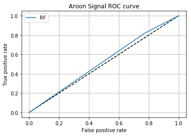

```python
X_aroon = aroon_side.values.reshape(-1,1)
y_aroon = aroon_bins.bin.values
X_aroon_train, X_aroon_test, y_aroon_train, y_aroon_test = train_test_split(X_aroon, y_aroon, test_size=0.3)

n_estimator = 300
aroon_random_forest = RandomForestClassifier(max_depth=2, n_estimators=n_estimator,
                            criterion='entropy', random_state=RANDOM_STATE)
aroon_random_forest.fit(X_aroon_train, y_aroon_train)

# The random forest model by itself
y_aroon_pred_random_forest = aroon_random_forest.predict_proba(X_aroon_test)[:, 1]
y_aroon_pred = aroon_random_forest.predict(X_aroon_test)
fpr_aroon_random_forest, tpr_aroon_random_forest, _ = roc_curve(y_aroon_test, y_aroon_pred_random_forest)

print("AUC:", roc_auc_score(y_aroon_test, y_aroon_pred_random_forest))
print()
print(classification_report(y_aroon_test, y_aroon_pred))
print("Confusion Matrix:")
print(confusion_matrix(y_aroon_test, y_aroon_pred))
print()
print("Accuracy Score:")
print(accuracy_score(y_aroon_test, y_aroon_pred))
print()
print("ROC Curve:")
plt.figure(1)
plt.plot([0, 1], [0, 1], 'k--')
plt.plot(fpr_aroon_random_forest, tpr_aroon_random_forest, label='RF')
plt.xlabel('False positive rate')
plt.ylabel('True positive rate')
plt.title('Aroon Signal ROC curve')
plt.legend(loc='best')
plt.grid()
plt.show()
```

We have used the following features in our model: Daily Volatility (of returns), serial correlation (indirectly, but we will consider it again below), MA crossover, RSI, and Aroon.

# SERIAL CORRELATION

```python
def returns(s):
    arr = np.diff(np.log(s))
    return (pd.Series(arr, index=s.index[1:]))

def df_rolling_autocorrelation(df, window, lag=1):
    """Compute rolling column-wise autocorrelation for a DataFrame."""

    return (df.rolling(window=window)
            .corr(df.shift(lag))) # could .dropna() here
```

```python
serial_correlation = df_rolling_autocorrelation(returns(close), window=14).rename('serial_corr')
serial_correlation.head(20)
```

```
End
2015-02-01 00:03:00         NaN
2015-02-01 00:07:00         NaN
2015-02-01 00:08:00         NaN
2015-02-01 00:09:00         NaN
2015-02-01 00:10:00         NaN
2015-02-01 00:14:00         NaN
2015-02-01 00:15:00         NaN
2015-02-01 00:20:00         NaN
2015-02-01 00:22:00         NaN
2015-02-01 00:25:00         NaN
2015-02-01 00:26:00         NaN
2015-02-01 00:27:00         NaN
2015-02-01 00:28:00         NaN
2015-02-01 00:29:00         NaN
2015-02-01 00:30:00   -0.173652
2015-02-01 00:31:00   -0.205367
2015-02-01 00:32:00   -0.386407
2015-02-01 00:33:00   -0.215306
2015-02-01 00:34:00   -0.024236
2015-02-01 00:35:00   -0.018670
Name: serial_corr, dtype: float64
```

```python
serial_correlation.shape
```

```
(1677761,)
```

# Combining features into a dataset for an actual model.

Here we take the strongest features (in terms of AUC, Accuracy, Classification, ROC characteristics) and combine them into a dataframe that we can use in a Random Forest Classifier. This is equivalent to finding the strongest signals from a combination of features. Aroon and RSI were the strongest predictors of signals, followed by MA so we'll use all 3, using Aroon to provide the target volatility because MA and RSI have a similar number of signals either side {1, -1} and we infer that many of them will align.

```python
features = (pd.DataFrame()
            .assign(vol=aroon_events.trgt)
            .assign(ma_side=ma_side)
            .assign(rsi_side=rsi_side)
            .assign(serial_corr=serial_correlation)
            .drop_duplicates()
            .dropna()
           )

features.shape
```

```
(304, 4)
```

```python
Xy = (pd.merge_asof(features, rsi_bins[['bin']],
                    left_index=True, right_index=True,
                    direction='forward').dropna())
Xy
```

|  | vol | ma_side | rsi_side | serial_corr | bin |
| --- | --- | --- | --- | --- | --- |
| 2015-02-05 13:12:00 | 0.031605 | -1.0 | 1.0 | -0.102854 | 0.0 |
| 2015-02-14 07:36:00 | 0.022917 | -1.0 | 1.0 | 0.253597 | 1.0 |
| 2015-02-14 22:35:00 | 0.022046 | -1.0 | 1.0 | 0.115082 | 1.0 |
| 2015-02-15 02:00:00 | 0.022574 | -1.0 | 1.0 | -0.198768 | 0.0 |
| 2015-02-15 15:27:00 | 0.027932 | -1.0 | 1.0 | 0.130611 | 0.0 |
| 2015-02-27 09:23:00 | 0.033953 | -1.0 | 1.0 | 0.418200 | 1.0 |
| 2015-03-03 11:52:00 | 0.019743 | -1.0 | 1.0 | -0.074347 | 1.0 |
| 2015-03-09 18:07:00 | 0.017216 | 1.0 | -1.0 | -0.110904 | 0.0 |
| 2015-03-18 22:37:00 | 0.031417 | 1.0 | -1.0 | 0.268930 | 0.0 |
| 2015-03-18 22:44:00 | 0.031687 | -1.0 | 1.0 | 0.263725 | 1.0 |
| 2015-03-19 01:46:00 | 0.035300 | 1.0 | -1.0 | 0.197066 | 0.0 |
| 2015-03-19 20:52:00 | 0.030706 | -1.0 | 1.0 | -0.271330 | 1.0 |
| 2015-03-24 10:33:00 | 0.018814 | 1.0 | -1.0 | 0.173475 | 1.0 |
| 2015-03-24 11:39:00 | 0.020766 | -1.0 | 1.0 | 0.393755 | 0.0 |
| 2015-03-25 07:20:00 | 0.029881 | -1.0 | 1.0 | -0.096716 | 1.0 |
| 2015-03-26 20:03:00 | 0.030691 | -1.0 | 1.0 | 0.044324 | 0.0 |
| 2015-04-06 21:24:00 | 0.014994 | 1.0 | -1.0 | 0.370611 | 1.0 |
| 2015-05-14 21:18:00 | 0.012467 | -1.0 | 1.0 | -0.021980 | 1.0 |
| 2015-07-10 14:40:00 | 0.026520 | -1.0 | 1.0 | 0.760437 | 1.0 |
| 2015-07-15 02:51:00 | 0.029391 | -1.0 | 1.0 | 0.330807 | 0.0 |
| 2015-07-16 14:18:00 | 0.017553 | 1.0 | -1.0 | 0.571924 | 1.0 |
| 2015-08-22 18:34:00 | 0.017216 | 1.0 | -1.0 | -0.215018 | 0.0 |
| 2015-08-24 12:53:00 | 0.018328 | 1.0 | -1.0 | 0.352585 | 1.0 |
| 2015-08-24 22:57:00 | 0.021763 | -1.0 | 1.0 | 0.019509 | 0.0 |
| 2015-08-26 13:52:00 | 0.047262 | 1.0 | -1.0 | -0.291422 | 1.0 |
| 2015-11-04 04:24:00 | 0.040807 | -1.0 | 1.0 | 0.457518 | 1.0 |
| 2015-11-04 10:38:00 | 0.033887 | 1.0 | -1.0 | 0.442200 | 0.0 |
| 2015-11-04 18:07:00 | 0.048618 | -1.0 | 1.0 | 0.355103 | 0.0 |
| 2015-11-04 23:50:00 | 0.079317 | -1.0 | 1.0 | 0.308642 | 1.0 |
| 2015-11-05 00:06:00 | 0.081177 | -1.0 | 1.0 | 0.739431 | 1.0 |
| ... | ... | ... | ... | ... | ... |
| 2018-03-15 02:06:00 | 0.042932 | -1.0 | 1.0 | 0.491944 | 1.0 |
| 2018-03-15 07:00:00 | 0.048464 | 1.0 | -1.0 | 0.322381 | 0.0 |
| 2018-03-15 08:37:00 | 0.046452 | 1.0 | -1.0 | -0.243008 | 0.0 |
| 2018-03-16 08:15:00 | 0.052050 | 1.0 | -1.0 | 0.388351 | 1.0 |
| 2018-03-17 13:34:00 | 0.022604 | -1.0 | 1.0 | 0.136905 | 0.0 |
| 2018-03-18 20:03:00 | 0.019330 | 1.0 | -1.0 | 0.489298 | 0.0 |
| 2018-03-18 21:46:00 | 0.022591 | 1.0 | -1.0 | 0.076841 | 0.0 |
| 2018-03-19 17:23:00 | 0.066215 | -1.0 | 1.0 | 0.226634 | 1.0 |
| 2018-03-22 08:57:00 | 0.026159 | 1.0 | -1.0 | 0.144681 | 1.0 |
| 2018-03-22 13:45:00 | 0.031378 | -1.0 | 1.0 | 0.442674 | 0.0 |
| 2018-03-26 12:22:00 | 0.015855 | 1.0 | -1.0 | 0.280888 | 1.0 |
| 2018-03-30 06:36:00 | 0.040479 | -1.0 | 1.0 | 0.476590 | 0.0 |
| 2018-03-30 15:59:00 | 0.029010 | 1.0 | -1.0 | 0.478321 | 0.0 |
| 2018-03-30 18:21:00 | 0.028422 | -1.0 | 1.0 | 0.192114 | 1.0 |
| 2018-03-31 11:16:00 | 0.044469 | -1.0 | 1.0 | 0.070989 | 0.0 |
| 2018-03-31 19:14:00 | 0.047630 | -1.0 | 1.0 | 0.541014 | 0.0 |
| 2018-04-05 17:22:00 | 0.031639 | 1.0 | -1.0 | 0.463403 | 1.0 |
| 2018-04-08 08:54:00 | 0.021629 | 1.0 | -1.0 | 0.279605 | 0.0 |
| 2018-04-16 12:38:00 | 0.023727 | -1.0 | 1.0 | 0.227629 | 1.0 |
| 2018-04-26 16:39:00 | 0.031103 | 1.0 | -1.0 | -0.079603 | 0.0 |
| 2018-04-29 03:30:00 | 0.021409 | -1.0 | 1.0 | 0.469611 | 0.0 |
| 2018-05-11 05:10:00 | 0.023670 | 1.0 | -1.0 | 0.516258 | 1.0 |
| 2018-05-23 17:45:00 | 0.017073 | -1.0 | 1.0 | 0.476647 | 1.0 |
| 2018-05-24 11:01:00 | 0.016451 | 1.0 | -1.0 | 0.425185 | 0.0 |
| 2018-05-24 17:33:00 | 0.019358 | 1.0 | -1.0 | 0.487698 | 1.0 |
| 2018-06-22 13:28:00 | 0.025569 | -1.0 | 1.0 | 0.472907 | 0.0 |
| 2018-07-05 09:59:00 | 0.012525 | 1.0 | -1.0 | 0.389628 | 1.0 |
| 2018-07-25 00:00:00 | 0.017713 | -1.0 | 1.0 | 0.245360 | 0.0 |
| 2018-09-29 23:06:00 | 0.012899 | 1.0 | -1.0 | 0.332044 | 0.0 |
| 2018-10-15 08:18:00 | 0.018745 | 1.0 | -1.0 | -0.106593 | 1.0 |

304 rows × 5 columns

**Establish a baseline RF Classifier model and scores that we aim to exceed, using the default Classifier settings. Train it with a 70/30 train/test split, make predictions on test data, and output scores. (#5, #6, #7, #8 in Solutions Document)**

Create X and y values from our features. We drop 'bin' as this is what we are trying to predict (trade or not).

```python
X = Xy.drop('bin',axis=1).values
y = Xy['bin'].values

print(X)
print(y)
```

```
[[ 0.03160477 -1.          1.         -0.10285427]
 [ 0.02291737 -1.          1.          0.2535969 ]
 [ 0.02204592 -1.          1.          0.11508155]
 ...
 [ 0.01771297 -1.          1.          0.24536014]
 [ 0.01289872  1.         -1.          0.3320444 ]
 [ 0.01874516  1.         -1.         -0.10659338]]
[0. 1. 1. 0. 0. 1. 1. 0. 0. 1. 0. 1. 1. 0. 1. 0. 1. 1. 1. 0. 1. 0. 1. 0.
 1. 1. 0. 0. 1. 1. 1. 1. 0. 1. 1. 1. 0. 1. 1. 1. 1. 0. 1. 1. 1. 0. 1. 1.
 1. 1. 1. 0. 1. 1. 1. 0. 1. 1. 1. 0. 0. 1. 0. 1. 1. 1. 0. 1. 1. 1. 0. 1.
 0. 0. 1. 1. 1. 0. 0. 0. 1. 1. 0. 1. 1. 0. 0. 0. 0. 0. 1. 0. 0. 1. 1. 1.
 1. 1. 1. 1. 0. 1. 0. 0. 0. 1. 0. 1. 1. 1. 0. 0. 1. 1. 0. 0. 1. 1. 0. 0.
 0. 1. 1. 1. 1. 1. 0. 1. 1. 0. 0. 1. 0. 1. 0. 1. 0. 0. 1. 0. 0. 0. 0. 0.
 0. 1. 1. 0. 1. 1. 0. 0. 0. 0. 0. 0. 0. 1. 1. 1. 1. 0. 0. 1. 1. 0. 1. 0.
 1. 0. 0. 1. 1. 1. 1. 1. 0. 1. 1. 0. 0. 1. 1. 1. 0. 1. 0. 1. 0. 0. 0. 1.
 0. 1. 1. 1. 1. 0. 1. 0. 1. 0. 0. 0. 1. 0. 0. 1. 1. 1. 0. 1. 1. 1. 0. 1.
 0. 1. 0. 0. 1. 0. 0. 0. 0. 0. 0. 1. 0. 1. 0. 0. 0. 0. 1. 1. 1. 0. 0. 1.
 1. 0. 0. 0. 0. 1. 1. 1. 0. 1. 0. 1. 0. 1. 1. 1. 0. 1. 1. 1. 0. 1. 0. 1.
 1. 0. 0. 1. 0. 1. 0. 0. 0. 0. 1. 0. 0. 1. 0. 0. 0. 1. 1. 0. 1. 0. 0. 1.
 0. 0. 1. 0. 1. 0. 0. 1. 1. 0. 1. 0. 1. 0. 0. 1.]
```

```python
X_train, X_test, y_train, y_test = train_test_split(X, y, test_size=0.3, shuffle=False)
```

```python
# print(X_test)
# print(y_test)
print(len(X_test))
```

```
92
```

```
AUC: 0.5511716881874701

Classification Report:
             precision    recall  f1-score   support

   no_trade       0.59      0.57      0.58        51
      trade       0.49      0.51      0.50        41

avg / total       0.55      0.54      0.54        92

Confusion Matrix:
[[29 22]
 [20 21]]

Accuracy Score:
0.5434782608695652

ROC Curve:
```

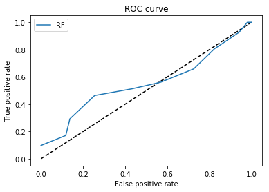

```python
rf = RandomForestClassifier(random_state=RANDOM_STATE)
rf.fit(X_train, y_train)

# The random forest model by itself
y_pred_rf = rf.predict_proba(X_test)[:, 1]
y_pred = rf.predict(X_test)
fpr_rf, tpr_rf, _ = roc_curve(y_test, y_pred_rf)

print("AUC:", roc_auc_score(y_test, y_pred_rf))
print()
print("Classification Report:")
print(classification_report(y_test, y_pred, target_names=['no_trade','trade']))
print("Confusion Matrix:")
print(confusion_matrix(y_test, y_pred))
print()
print("Accuracy Score:")
print(accuracy_score(y_test, y_pred))
print()
print("ROC Curve:")
plt.figure(1)
plt.plot([0, 1], [0, 1], 'k--')
plt.plot(fpr_rf, tpr_rf, label='RF')
plt.xlabel('False positive rate')
plt.ylabel('True positive rate')
plt.title('ROC curve')
plt.legend(loc='best')
plt.show()
```

This is pretty good (although it is becoming clear to us that dePrado's triple barrier methods may be suited more to HFT trading/scalping). We will be hard pressed to get more data from these techniques, so we will need to try hyperparameter tuning to see if we can improve the baseline (while being careful not to overfit).

**Hyperparameter Tuning (#9 in Solutions Document)**

Examine the default parameters of the Random Forest Classifier

```python
rf_cl = RandomForestClassifier(random_state = RANDOM_STATE)
# Look at default parameters used by our current forest
print('Parameters currently in use:\n')
pprint(rf_cl.get_params())
```

```
Parameters currently in use:

{'bootstrap': True,
 'class_weight': None,
 'criterion': 'gini',
 'max_depth': None,
 'max_features': 'auto',
 'max_leaf_nodes': None,
 'min_impurity_decrease': 0.0,
 'min_impurity_split': None,
 'min_samples_leaf': 1,
 'min_samples_split': 2,
 'min_weight_fraction_leaf': 0.0,
 'n_estimators': 10,
 'n_jobs': 1,
 'oob_score': False,
 'random_state': 42,
 'verbose': 0,
 'warm_start': False}
```

Fortunately, scikit-learn comes with sklearn.model_selection.RandomizedSearchCV and sklearn.model_selection.GridSearchCV which allows us to perform randomized and grid searches on hyperparameters. We also import StratifiedKFold in order to perform K-Fold Cross-Validation.

```python
from sklearn.model_selection import RandomizedSearchCV, GridSearchCV, StratifiedKFold
```

```python
# n_estimators controls the number of trees in the random forest
# Here we step 10 between 200 and 2000
n_estimators = [int(x) for x in np.linspace(start = 200, stop = 2000, num = 10)]

# Number of features to consider at every split
max_features = ['auto', 'sqrt']

# Maximum number of levels in tree
max_depth = [int(x) for x in np.linspace(10, 110, num = 11)]
max_depth.append(None)

# Minimum number of samples required to split a node
min_samples_split = [2, 5, 10]

# Minimum number of samples required at each leaf node
min_samples_leaf = [1, 2, 4]

# Method of selecting samples for training each tree
bootstrap = [True, False]

# Create the random grid
random_grid = {'n_estimators': n_estimators,
               'max_features': max_features,
               'max_depth': max_depth,
               'min_samples_split': min_samples_split,
               'min_samples_leaf': min_samples_leaf,
               'bootstrap': bootstrap}

pprint(random_grid)
```

```
{'bootstrap': [True, False],
 'max_depth': [10, 20, 30, 40, 50, 60, 70, 80, 90, 100, 110, None],
 'max_features': ['auto', 'sqrt'],
 'min_samples_leaf': [1, 2, 4],
 'min_samples_split': [2, 5, 10],
 'n_estimators': [200, 400, 600, 800, 1000, 1200, 1400, 1600, 1800, 2000]}
```

Use the random grid to search for best hyperparameters. First create the base model to tune and then apply the random grid 100 times on 3-fold cross-validation (3x100 in parallel). **NOTE:** using verbose=False to avoid too much output. Then print out the best hyperparameters.

```python
rf = RandomForestClassifier()
# Random search of parameters, using 3 fold cross validation,
# search across 100 different combinations, and use all available cores
rf_random = RandomizedSearchCV(estimator = rf, param_distributions = random_grid, n_iter = 100, cv = 3, verbose=False, random_state=42, n_jobs = -1)
# Fit the random search model
rf_random.fit(X_train, y_train)
```

```
RandomizedSearchCV(cv=3, error_score='raise',
          estimator=RandomForestClassifier(bootstrap=True, class_weight=None, criterion='gini',
            max_depth=None, max_features='auto', max_leaf_nodes=None,
            min_impurity_decrease=0.0, min_impurity_split=None,
            min_samples_leaf=1, min_samples_split=2,
            min_weight_fraction_leaf=0.0, n_estimators=10, n_jobs=1,
            oob_score=False, random_state=None, verbose=0,
            warm_start=False),
          fit_params=None, iid=True, n_iter=100, n_jobs=-1,
          param_distributions={'n_estimators': [200, 400, 600, 800, 1000, 1200, 1400, 1600, 1800, 2000], 'max_features': ['auto', 'sqrt'], 'max_depth': [10, 20, 30, 40, 50, 60, 70, 80, 90, 100, 110, None], 'min_samples_split': [2, 5, 10], 'min_samples_leaf': [1, 2, 4], 'bootstrap': [True, False]},
          pre_dispatch='2*n_jobs', random_state=42, refit=True,
          return_train_score='warn', scoring=None, verbose=False)
```

```python
rf_random.best_params_
```

```
{'n_estimators': 1600,
 'min_samples_split': 10,
 'min_samples_leaf': 1,
 'max_features': 'sqrt',
 'max_depth': None,
 'bootstrap': True}
```

Now we rerun the model using the optimized hyperparameters, so see if the accuracy has improved.

```
AUC: 0.5600191296030607

Classification Report:
             precision    recall  f1-score   support

   no_trade       0.62      0.47      0.53        51
      trade       0.49      0.63      0.55        41

avg / total       0.56      0.54      0.54        92

Confusion Matrix:
[[24 27]
 [15 26]]

Accuracy Score:
0.5434782608695652

ROC Curve:
```

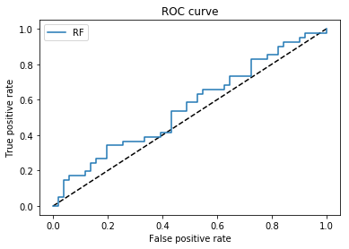

```python
rf_opt = RandomForestClassifier(n_estimators=1600,
                                min_samples_split=10,
                                min_samples_leaf=1,
                                max_features='sqrt',
                                max_depth=None,
                                bootstrap=True,
                                random_state=RANDOM_STATE)
rf_opt.fit(X_train, y_train)

# The random forest model by itself
y_pred_rf_opt = rf_opt.predict_proba(X_test)[:, 1]
y_pred_opt = rf_opt.predict(X_test)
fpr_rf_opt, tpr_rf_opt, _ = roc_curve(y_test, y_pred_rf_opt)

print("AUC:", roc_auc_score(y_test, y_pred_rf_opt))
print()
print("Classification Report:")
print(classification_report(y_test, y_pred_opt, target_names=['no_trade','trade']))
print("Confusion Matrix:")
print(confusion_matrix(y_test, y_pred_opt))
print()
print("Accuracy Score:")
print(accuracy_score(y_test, y_pred_opt))
print()
print("ROC Curve:")
plt.figure(1)
plt.plot([0, 1], [0, 1], 'k--')
plt.plot(fpr_rf_opt, tpr_rf_opt, label='RF')
plt.xlabel('False positive rate')
plt.ylabel('True positive rate')
plt.title('ROC curve')
plt.legend(loc='best')
plt.show()
```

We have no real improvement in accuracy from from RandomizedSearchCV hyperparameter tuning, but there is a small gain in AUC from 0.551 to 0.56, with most of the curve above the "luck line". We can try Stratified K-Fold Cross-Validation using the parameters suggested by RandomizedSearchCV.

Now we are going to try using Stratified K-Fold Cross-Validation on 5 folds using the best parameters from RandomizedSearchCV. In order to plot AUC values for each fold, we have added a couple of functions (one is in the module plot_roc_curve).

Taken from example at:

```
* https://scikit-learn.org/stable/auto_examples/model_selection/plot_roc_crossval.html
```

```python
def compute_roc_auc_rs(index):
    # Use the Gridsearch optimized classifier (rf_opt_gs)
    y_predict = rf_opt.predict_proba(X[index])[:,1]
    # print(y_predict.shape)
    # print(y[index].shape)
    fpr, tpr, thresholds = roc_curve(y[index], y_predict)
    auc_score = auc(fpr, tpr)
    return fpr, tpr, auc_score
```

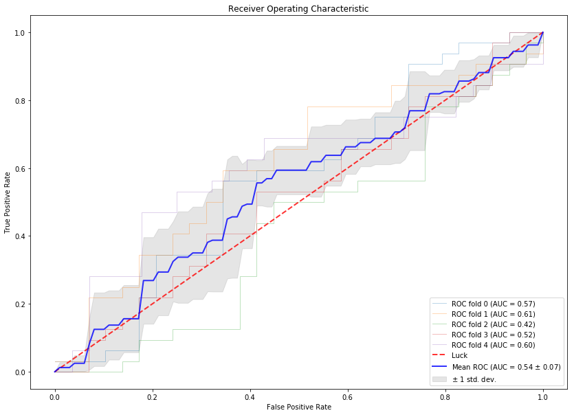

|  | AUC Train | AUC Test |
| --- | --- | --- |
| 0 | 0.968342 | 0.566810 |
| 1 | 0.972283 | 0.609914 |
| 2 | 0.975611 | 0.421336 |
| 3 | 0.966916 | 0.517241 |
| 4 | 0.968279 | 0.600446 |

```python
cross_val = StratifiedKFold(n_splits=5, random_state=42, shuffle=True)
fprs, tprs, scores = [], [], []

for (train, test), i in zip(cross_val.split(X, y), range(5)):
    rf_opt.fit(X[train], y[train])
    _, _, auc_score_train = compute_roc_auc_rs(train)
    fpr, tpr, auc_score = compute_roc_auc_rs(test)
    scores.append((auc_score_train, auc_score))
    fprs.append(fpr)
    tprs.append(tpr)

plot_roc_curve.plot_roc_curve(fprs, tprs);
pd.DataFrame(scores, columns=['AUC Train', 'AUC Test'])
```

There is not really an improvement of AUC, unless you consider the standard deviation from the mean, using Stratified K-Fold Cross-Validation on Randomized search CV parameters.

Now let's try GridSearchCV on a series of parameters around those suggested by RandomizedSearchCV. GridSearchCV is computationally intensive as it searches across all combinations, and takes a long time.

```python
# Create the narrower parameter grid based on the results of randomized search CV
param_grid = {
    'bootstrap': [True],
    'max_depth': [90, 100, 110, None],
    'max_features': ['auto', 'sqrt'],
    'min_samples_leaf': [1, 2, 3],
    'min_samples_split': [8, 10, 12],
    'n_estimators': [1400, 1500, 1600, 1700, 1800]
}
# Create a based model
rf_gs = RandomForestClassifier()
# Instantiate the grid search model
rf_grid_search = GridSearchCV(estimator = rf_gs, param_grid = param_grid,
                          cv = 3, n_jobs = -1, verbose = False)
rf_grid_search.fit(X_train, y_train)
```

```
GridSearchCV(cv=3, error_score='raise',
       estimator=RandomForestClassifier(bootstrap=True, class_weight=None, criterion='gini',
            max_depth=None, max_features='auto', max_leaf_nodes=None,
            min_impurity_decrease=0.0, min_impurity_split=None,
            min_samples_leaf=1, min_samples_split=2,
            min_weight_fraction_leaf=0.0, n_estimators=10, n_jobs=1,
            oob_score=False, random_state=None, verbose=0,
            warm_start=False),
       fit_params=None, iid=True, n_jobs=-1,
       param_grid={'bootstrap': [True], 'max_depth': [90, 100, 110, None], 'max_features': ['auto', 'sqrt'], 'min_samples_leaf': [1, 2, 3], 'min_samples_split': [8, 10, 12], 'n_estimators': [1400, 1500, 1600, 1700, 1800]},
       pre_dispatch='2*n_jobs', refit=True, return_train_score='warn',
       scoring=None, verbose=False)
```

Show the best parameters from the grid search and add them to the classifier to see if there is improvement.

```python
rf_grid_search.best_params_
```

```
{'bootstrap': True,
 'max_depth': 90,
 'max_features': 'auto',
 'min_samples_leaf': 1,
 'min_samples_split': 12,
 'n_estimators': 1800}
```

```
AUC: 0.5662362505978001

Classification Report:
             precision    recall  f1-score   support

   no_trade       0.63      0.47      0.54        51
      trade       0.50      0.66      0.57        41

avg / total       0.57      0.55      0.55        92

Confusion Matrix:
[[24 27]
 [14 27]]

Accuracy Score:
0.5543478260869565

ROC Curve:
```

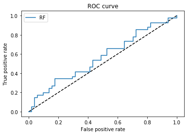

```python
rf_opt_gs = RandomForestClassifier(n_estimators=1800,
                                min_samples_split=12,
                                min_samples_leaf=1,
                                max_features='auto',
                                max_depth=90,
                                bootstrap=True,
                                random_state=RANDOM_STATE)
rf_opt_gs.fit(X_train, y_train)

# The random forest model by itself
y_pred_rf_opt_gs = rf_opt_gs.predict_proba(X_test)[:, 1]
y_pred_opt_gs = rf_opt_gs.predict(X_test)
fpr_rf_opt_gs, tpr_rf_opt_gs, _ = roc_curve(y_test, y_pred_rf_opt_gs)

print("AUC:", roc_auc_score(y_test, y_pred_rf_opt_gs))
print()
print("Classification Report:")
print(classification_report(y_test, y_pred_opt_gs, target_names=['no_trade','trade']))
print("Confusion Matrix:")
print(confusion_matrix(y_test, y_pred_opt_gs))
print()
print("Accuracy Score:")
print(accuracy_score(y_test, y_pred_opt_gs))
print()
print("ROC Curve:")
plt.figure(1)
plt.plot([0, 1], [0, 1], 'k--')
plt.plot(fpr_rf_opt_gs, tpr_rf_opt_gs, label='RF')
plt.xlabel('False positive rate')
plt.ylabel('True positive rate')
plt.title('ROC curve')
plt.legend(loc='best')
plt.show()
```

Both AUC and Accuracy have improved with the parameters selected by grid search, to 0.566 and 0.554 respectively, a slight gain over the randomized search cv scores. We can now try these grid search parameters with Stratified K-Fold Cross-Validation, in the same way as before.

```python
def compute_roc_auc_gs(index):
    # Use the Gridsearch optimized classifier (rf_opt_gs)
    y_predict = rf_opt_gs.predict_proba(X[index])[:,1]
    # print(y_predict.shape)
    # print(y[index].shape)
    fpr, tpr, thresholds = roc_curve(y[index], y_predict)
    auc_score = auc(fpr, tpr)
    return fpr, tpr, auc_score
```

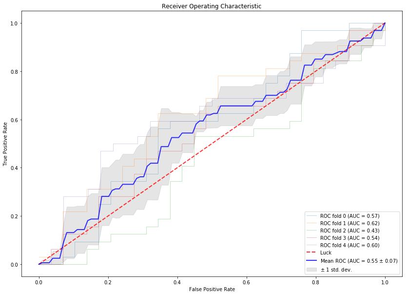

|  | AUC Train | AUC Test |
| --- | --- | --- |
| 0 | 0.953533 | 0.574353 |
| 1 | 0.961957 | 0.618534 |
| 2 | 0.965421 | 0.433190 |
| 3 | 0.952446 | 0.540948 |
| 4 | 0.952788 | 0.597098 |

```python
cross_val = StratifiedKFold(n_splits=5, random_state=42, shuffle=True)
fprs, tprs, scores = [], [], []

for (train, test), i in zip(cross_val.split(X, y), range(5)):
    rf_opt_gs.fit(X[train], y[train])
    _, _, auc_score_train = compute_roc_auc_gs(train)
    fpr, tpr, auc_score = compute_roc_auc_gs(test)
    scores.append((auc_score_train, auc_score))
    fprs.append(fpr)
    tprs.append(tpr)

plot_roc_curve.plot_roc_curve(fprs, tprs);
pd.DataFrame(scores, columns=['AUC Train', 'AUC Test'])
```

Stratification seeks to ensure that each fold is representative of all strata of the data. Generally this is done in a supervised way for classification and aims to ensure each class is (approximately) equally represented across each test fold (which are of course combined in a complementary way to form training folds).

The intuition behind this relates to the bias of most classification algorithms. They tend to weight each instance equally which means overrepresented classes get too much weight (e.g. optimizing F-measure, Accuracy or a complementary form of error).

Join X_test portion of Xy with y_pred to compute returns. First, examine the test bin data vs the predicted bin data.

```python
print(y_test)
print(y_pred_opt_gs)
```

```
[1. 1. 0. 1. 0. 1. 0. 0. 1. 0. 0. 0. 0. 0. 0. 1. 0. 1. 0. 0. 0. 0. 1. 1.
 1. 0. 0. 1. 1. 0. 0. 0. 0. 1. 1. 1. 0. 1. 0. 1. 0. 1. 1. 1. 0. 1. 1. 1.
 0. 1. 0. 1. 1. 0. 0. 1. 0. 1. 0. 0. 0. 0. 1. 0. 0. 1. 0. 0. 0. 1. 1. 0.
 1. 0. 0. 1. 0. 0. 1. 0. 1. 0. 0. 1. 1. 0. 1. 0. 1. 0. 0. 1.]
[0. 1. 1. 1. 1. 1. 0. 0. 0. 0. 0. 0. 0. 1. 0. 0. 1. 1. 1. 0. 0. 0. 1. 0.
 0. 1. 0. 1. 1. 1. 0. 1. 1. 0. 1. 1. 0. 0. 1. 1. 0. 0. 1. 1. 1. 0. 1. 1.
 0. 1. 1. 1. 0. 0. 1. 1. 1. 0. 1. 0. 0. 0. 0. 0. 1. 0. 1. 1. 1. 1. 1. 1.
 1. 0. 1. 1. 1. 0. 1. 1. 1. 1. 0. 1. 0. 1. 1. 0. 1. 1. 1. 1.]
```

Below we obtain the last 92 rows of our Xy data that represent our out-of-sample test set, and append the predicted bin value (y_pred_opt_gs) as "pred_bin". Then add the ClosePrice from the corresponding volume bar as "close_price". That way we can calculate actual returns (from combining real returns with the desired bin values) and predicted returns (from combining real returns with the bin values predicted by our model on our out-of-sample data), using a simple vectorized backtest. One problem with the combined model is that it only predicts whether to trade or not, it does not determine a side. So we will compute returns for all long trades, and all short trades separately. For short trades we multiply the binary value by -1. We will explain this challgnge and how we might handle side prediction further in our report.

```python
results = pd.DataFrame(Xy)[-92:]
results['pred_bin'] = y_pred_opt_gs
results['close_price'] = dollar_bars_ohlc.loc[results.index]['ClosePrice']
results['real_returns_l'] = np.log(results['close_price'] / results['close_price'].shift(1))
results['actual_returns_l'] =  results['bin'] * results['real_returns_l']
results['pred_returns_l'] =  results['pred_bin'] * results['real_returns_l']
results['real_returns_s'] = results['real_returns_l'] * -1
results['actual_returns_s'] = results['actual_returns_l'] * -1
results['pred_returns_s'] = results['pred_returns_l'] * -1
results.dropna(inplace=True)
results
```

|  | vol | ma_side | rsi_side | serial_corr | bin | pred_bin | close_price | real_returns_l | actual_returns_l | pred_returns_l | real_returns_s | actual_returns_s | pred_returns_s |
| --- | --- | --- | --- | --- | --- | --- | --- | --- | --- | --- | --- | --- | --- |
| 2018-01-11 20:15:00 | 0.026410 | -1.0 | 1.0 | 0.241919 | 1.0 | 1.0 | 13327.823518 | -0.102494 | -0.102494 | -0.102494 | 0.102494 | 0.102494 | 0.102494 |
| 2018-01-11 23:55:00 | 0.032369 | 1.0 | -1.0 | -0.155173 | 0.0 | 1.0 | 13251.302169 | -0.005758 | -0.000000 | -0.005758 | 0.005758 | 0.000000 | 0.005758 |
| 2018-01-12 05:14:00 | 0.043986 | -1.0 | 1.0 | 0.470528 | 1.0 | 1.0 | 13642.676540 | 0.029107 | 0.029107 | 0.029107 | -0.029107 | -0.029107 | -0.029107 |
| 2018-01-16 01:01:00 | 0.031681 | -1.0 | 1.0 | 0.239081 | 0.0 | 1.0 | 13182.241281 | -0.034332 | -0.000000 | -0.034332 | 0.034332 | 0.000000 | 0.034332 |
| 2018-01-16 04:33:00 | 0.035541 | 1.0 | -1.0 | 0.784879 | 1.0 | 1.0 | 13015.103081 | -0.012760 | -0.012760 | -0.012760 | 0.012760 | 0.012760 | 0.012760 |
| 2018-01-17 16:44:00 | 0.048559 | 1.0 | -1.0 | 0.372882 | 0.0 | 0.0 | 10126.273492 | -0.250977 | -0.000000 | -0.000000 | 0.250977 | 0.000000 | 0.000000 |
| 2018-01-17 19:35:00 | 0.043414 | 1.0 | -1.0 | 0.478199 | 0.0 | 0.0 | 10248.440744 | 0.011992 | 0.000000 | 0.000000 | -0.011992 | -0.000000 | -0.000000 |
| 2018-01-18 02:51:00 | 0.086152 | 1.0 | -1.0 | 0.000433 | 1.0 | 0.0 | 11734.889520 | 0.135441 | 0.135441 | 0.000000 | -0.135441 | -0.135441 | -0.000000 |
| 2018-01-18 06:01:00 | 0.088839 | 1.0 | -1.0 | 0.164255 | 0.0 | 0.0 | 11084.586708 | -0.057011 | -0.000000 | -0.000000 | 0.057011 | 0.000000 | 0.000000 |
| 2018-01-18 10:43:00 | 0.080272 | 1.0 | -1.0 | -0.061557 | 0.0 | 0.0 | 11270.929493 | 0.016671 | 0.000000 | 0.000000 | -0.016671 | -0.000000 | -0.000000 |
| 2018-01-18 16:01:00 | 0.124253 | -1.0 | 1.0 | 0.335998 | 0.0 | 0.0 | 11945.526144 | 0.058130 | 0.000000 | 0.000000 | -0.058130 | -0.000000 | -0.000000 |
| 2018-01-18 22:56:00 | 0.103604 | -1.0 | 1.0 | 0.496071 | 0.0 | 0.0 | 11327.479332 | -0.053125 | -0.000000 | -0.000000 | 0.053125 | 0.000000 | 0.000000 |
| 2018-01-19 08:07:00 | 0.078141 | 1.0 | -1.0 | -0.265057 | 0.0 | 1.0 | 11521.152804 | 0.016953 | 0.000000 | 0.016953 | -0.016953 | -0.000000 | -0.016953 |
| 2018-01-19 20:43:00 | 0.056289 | 1.0 | -1.0 | 0.662587 | 0.0 | 0.0 | 11316.233001 | -0.017946 | -0.000000 | -0.000000 | 0.017946 | 0.000000 | 0.000000 |
| 2018-01-20 07:43:00 | 0.049416 | 1.0 | -1.0 | 0.304179 | 1.0 | 0.0 | 12521.992922 | 0.101248 | 0.101248 | 0.000000 | -0.101248 | -0.101248 | -0.000000 |
| 2018-01-22 01:41:00 | 0.065773 | -1.0 | 1.0 | 0.087156 | 0.0 | 1.0 | 11421.098563 | -0.092024 | -0.000000 | -0.092024 | 0.092024 | 0.000000 | 0.092024 |
| 2018-01-22 20:52:00 | 0.037857 | -1.0 | 1.0 | -0.246145 | 1.0 | 1.0 | 10362.324303 | -0.097286 | -0.097286 | -0.097286 | 0.097286 | 0.097286 | 0.097286 |
| 2018-01-23 00:22:00 | 0.033209 | -1.0 | 1.0 | 0.007977 | 0.0 | 1.0 | 10751.919834 | 0.036908 | 0.000000 | 0.036908 | -0.036908 | -0.000000 | -0.036908 |
| 2018-01-23 04:55:00 | 0.027443 | -1.0 | 1.0 | 0.387797 | 0.0 | 0.0 | 10733.163980 | -0.001746 | -0.000000 | -0.000000 | 0.001746 | 0.000000 | 0.000000 |
| 2018-01-23 15:14:00 | 0.033309 | 1.0 | -1.0 | 0.368885 | 0.0 | 0.0 | 10471.746458 | -0.024658 | -0.000000 | -0.000000 | 0.024658 | 0.000000 | 0.000000 |
| 2018-01-28 07:44:00 | 0.020132 | -1.0 | 1.0 | 0.405173 | 0.0 | 0.0 | 11578.160502 | 0.100440 | 0.000000 | 0.000000 | -0.100440 | -0.000000 | -0.000000 |
| 2018-01-29 12:00:00 | 0.027415 | 1.0 | -1.0 | 0.681922 | 1.0 | 1.0 | 10944.465851 | -0.056287 | -0.056287 | -0.056287 | 0.056287 | 0.056287 | 0.056287 |
| 2018-01-30 18:43:00 | 0.029216 | -1.0 | 1.0 | 0.554685 | 1.0 | 0.0 | 9820.790151 | -0.108332 | -0.108332 | -0.000000 | 0.108332 | 0.108332 | 0.000000 |
| 2018-01-31 02:33:00 | 0.038805 | -1.0 | 1.0 | 0.486109 | 1.0 | 0.0 | 9771.240770 | -0.005058 | -0.005058 | -0.000000 | 0.005058 | 0.005058 | 0.000000 |
| 2018-01-31 13:04:00 | 0.026188 | -1.0 | 1.0 | 0.707987 | 0.0 | 1.0 | 10206.758464 | 0.043607 | 0.000000 | 0.043607 | -0.043607 | -0.000000 | -0.043607 |
| 2018-02-02 13:51:00 | 0.042887 | 1.0 | -1.0 | 0.253348 | 0.0 | 0.0 | 8502.733755 | -0.182662 | -0.000000 | -0.000000 | 0.182662 | 0.000000 | 0.000000 |
| 2018-02-02 22:00:00 | 0.055323 | -1.0 | 1.0 | 0.037884 | 1.0 | 1.0 | 8554.961620 | 0.006124 | 0.006124 | 0.006124 | -0.006124 | -0.006124 | -0.006124 |
| 2018-02-03 01:05:00 | 0.054043 | -1.0 | 1.0 | 0.698223 | 1.0 | 1.0 | 8656.342307 | 0.011781 | 0.011781 | 0.011781 | -0.011781 | -0.011781 | -0.011781 |
| 2018-02-04 16:47:00 | 0.067423 | -1.0 | 1.0 | 0.110505 | 0.0 | 1.0 | 8350.575120 | -0.035962 | -0.000000 | -0.035962 | 0.035962 | 0.000000 | 0.035962 |
| 2018-02-06 11:32:00 | 0.052971 | 1.0 | -1.0 | -0.008372 | 0.0 | 0.0 | 6336.684929 | -0.275975 | -0.000000 | -0.000000 | 0.275975 | 0.000000 | 0.000000 |
| ... | ... | ... | ... | ... | ... | ... | ... | ... | ... | ... | ... | ... | ... |
| 2018-03-15 02:06:00 | 0.042932 | -1.0 | 1.0 | 0.491944 | 1.0 | 0.0 | 8053.254034 | -0.121275 | -0.121275 | -0.000000 | 0.121275 | 0.121275 | 0.000000 |
| 2018-03-15 07:00:00 | 0.048464 | 1.0 | -1.0 | 0.322381 | 0.0 | 0.0 | 7885.928773 | -0.020996 | -0.000000 | -0.000000 | 0.020996 | 0.000000 | 0.000000 |
| 2018-03-15 08:37:00 | 0.046452 | 1.0 | -1.0 | -0.243008 | 0.0 | 1.0 | 7884.683518 | -0.000158 | -0.000000 | -0.000158 | 0.000158 | 0.000000 | 0.000158 |
| 2018-03-16 08:15:00 | 0.052050 | 1.0 | -1.0 | 0.388351 | 1.0 | 0.0 | 8244.997447 | 0.044685 | 0.044685 | 0.000000 | -0.044685 | -0.044685 | -0.000000 |
| 2018-03-17 13:34:00 | 0.022604 | -1.0 | 1.0 | 0.136905 | 0.0 | 1.0 | 7989.325465 | -0.031500 | -0.000000 | -0.031500 | 0.031500 | 0.000000 | 0.031500 |
| 2018-03-18 20:03:00 | 0.019330 | 1.0 | -1.0 | 0.489298 | 0.0 | 1.0 | 7505.622662 | -0.062454 | -0.000000 | -0.062454 | 0.062454 | 0.000000 | 0.062454 |
| 2018-03-18 21:46:00 | 0.022591 | 1.0 | -1.0 | 0.076841 | 0.0 | 1.0 | 7993.603544 | 0.062989 | 0.000000 | 0.062989 | -0.062989 | -0.000000 | -0.062989 |
| 2018-03-19 17:23:00 | 0.066215 | -1.0 | 1.0 | 0.226634 | 1.0 | 1.0 | 8299.832903 | 0.037594 | 0.037594 | 0.037594 | -0.037594 | -0.037594 | -0.037594 |
| 2018-03-22 08:57:00 | 0.026159 | 1.0 | -1.0 | 0.144681 | 1.0 | 1.0 | 8995.010095 | 0.080435 | 0.080435 | 0.080435 | -0.080435 | -0.080435 | -0.080435 |
| 2018-03-22 13:45:00 | 0.031378 | -1.0 | 1.0 | 0.442674 | 0.0 | 1.0 | 8658.225807 | -0.038160 | -0.000000 | -0.038160 | 0.038160 | 0.000000 | 0.038160 |
| 2018-03-26 12:22:00 | 0.015855 | 1.0 | -1.0 | 0.280888 | 1.0 | 1.0 | 8090.585362 | -0.067809 | -0.067809 | -0.067809 | 0.067809 | 0.067809 | 0.067809 |
| 2018-03-30 06:36:00 | 0.040479 | -1.0 | 1.0 | 0.476590 | 0.0 | 0.0 | 7080.609798 | -0.133341 | -0.000000 | -0.000000 | 0.133341 | 0.000000 | 0.000000 |
| 2018-03-30 15:59:00 | 0.029010 | 1.0 | -1.0 | 0.478321 | 0.0 | 1.0 | 6778.124384 | -0.043660 | -0.000000 | -0.043660 | 0.043660 | 0.000000 | 0.043660 |
| 2018-03-30 18:21:00 | 0.028422 | -1.0 | 1.0 | 0.192114 | 1.0 | 1.0 | 6680.100566 | -0.014567 | -0.014567 | -0.014567 | 0.014567 | 0.014567 | 0.014567 |
| 2018-03-31 11:16:00 | 0.044469 | -1.0 | 1.0 | 0.070989 | 0.0 | 1.0 | 7064.234710 | 0.055912 | 0.000000 | 0.055912 | -0.055912 | -0.000000 | -0.055912 |
| 2018-03-31 19:14:00 | 0.047630 | -1.0 | 1.0 | 0.541014 | 0.0 | 0.0 | 7015.929582 | -0.006861 | -0.000000 | -0.000000 | 0.006861 | 0.000000 | 0.000000 |
| 2018-04-05 17:22:00 | 0.031639 | 1.0 | -1.0 | 0.463403 | 1.0 | 1.0 | 6775.248113 | -0.034907 | -0.034907 | -0.034907 | 0.034907 | 0.034907 | 0.034907 |
| 2018-04-08 08:54:00 | 0.021629 | 1.0 | -1.0 | 0.279605 | 0.0 | 1.0 | 6956.926249 | 0.026462 | 0.000000 | 0.026462 | -0.026462 | -0.000000 | -0.026462 |
| 2018-04-16 12:38:00 | 0.023727 | -1.0 | 1.0 | 0.227629 | 1.0 | 1.0 | 7992.315835 | 0.138743 | 0.138743 | 0.138743 | -0.138743 | -0.138743 | -0.138743 |
| 2018-04-26 16:39:00 | 0.031103 | 1.0 | -1.0 | -0.079603 | 0.0 | 1.0 | 8867.377007 | 0.103898 | 0.000000 | 0.103898 | -0.103898 | -0.000000 | -0.103898 |
| 2018-04-29 03:30:00 | 0.021409 | -1.0 | 1.0 | 0.469611 | 0.0 | 0.0 | 9431.911885 | 0.061720 | 0.000000 | 0.000000 | -0.061720 | -0.000000 | -0.000000 |
| 2018-05-11 05:10:00 | 0.023670 | 1.0 | -1.0 | 0.516258 | 1.0 | 1.0 | 8966.527907 | -0.050600 | -0.050600 | -0.050600 | 0.050600 | 0.050600 | 0.050600 |
| 2018-05-23 17:45:00 | 0.017073 | -1.0 | 1.0 | 0.476647 | 1.0 | 0.0 | 7511.409629 | -0.177075 | -0.177075 | -0.000000 | 0.177075 | 0.177075 | 0.000000 |
| 2018-05-24 11:01:00 | 0.016451 | 1.0 | -1.0 | 0.425185 | 0.0 | 1.0 | 7362.472147 | -0.020027 | -0.000000 | -0.020027 | 0.020027 | 0.000000 | 0.020027 |
| 2018-05-24 17:33:00 | 0.019358 | 1.0 | -1.0 | 0.487698 | 1.0 | 1.0 | 7519.135774 | 0.021055 | 0.021055 | 0.021055 | -0.021055 | -0.021055 | -0.021055 |
| 2018-06-22 13:28:00 | 0.025569 | -1.0 | 1.0 | 0.472907 | 0.0 | 0.0 | 6211.797820 | -0.191001 | -0.000000 | -0.000000 | 0.191001 | 0.000000 | 0.000000 |
| 2018-07-05 09:59:00 | 0.012525 | 1.0 | -1.0 | 0.389628 | 1.0 | 1.0 | 6637.059998 | 0.066219 | 0.066219 | 0.066219 | -0.066219 | -0.066219 | -0.066219 |
| 2018-07-25 00:00:00 | 0.017713 | -1.0 | 1.0 | 0.245360 | 0.0 | 1.0 | 8385.563815 | 0.233843 | 0.000000 | 0.233843 | -0.233843 | -0.000000 | -0.233843 |
| 2018-09-29 23:06:00 | 0.012899 | 1.0 | -1.0 | 0.332044 | 0.0 | 1.0 | 6593.992583 | -0.240353 | -0.000000 | -0.240353 | 0.240353 | 0.000000 | 0.240353 |
| 2018-10-15 08:18:00 | 0.018745 | 1.0 | -1.0 | -0.106593 | 1.0 | 1.0 | 6448.314298 | -0.022340 | -0.022340 | -0.022340 | 0.022340 | 0.022340 | 0.022340 |

91 rows × 13 columns

Here, "real_returns" represents buy and hold over the period of the 92 dollar bars in the test set; "actual_returns" represents what the returns from our model would be if it was 100% accurate - i.e. if it matched the binary output from our Xy dataset, and "pred_returns" represents the returns the model's predictions generated. For the long-only results, we are doing better than buy and hold, but **crucially** with less exposure and a lower standard deviation. Even though the model achieved a binary prediction accuracy of 55.4%, it seemed to do so in such a way that left out a lot of the bad trades! For the short-only results, sell and hold short BTC would have done best but, we are not sure if BTC is a shortable instrument, unless you completely hedged your BTC by converting it to dollars at the start of the period and converted it back to BTC at the end, which may be impractical and exposes you to currency risk also.

Absolute returns Long first then Short

```python
np.exp(results[['real_returns_l', 'actual_returns_l', 'pred_returns_l']].sum())
```

```
real_returns_l      0.436691
actual_returns_l    1.022107
pred_returns_l      1.115545
dtype: float64
```

Predicted returns (long only) returned 11.55% over the period.

```python
np.exp(results[['real_returns_s', 'actual_returns_s', 'pred_returns_s']].sum())
```

```
real_returns_s      2.289947
actual_returns_s    0.978371
pred_returns_s      0.896423
dtype: float64
```

Standard Deviation of Returns over the period. Long first then Short

```python
results[['real_returns_l', 'actual_returns_l', 'pred_returns_l']].std()
```

```
real_returns_l      0.087402
actual_returns_l    0.049597
pred_returns_l      0.059908
dtype: float64
```

```python
results[['real_returns_s', 'actual_returns_s', 'pred_returns_s']].std()
```

```
real_returns_s      0.087402
actual_returns_s    0.049597
pred_returns_s      0.059908
dtype: float64
```

Calculate Drawdowns

```python
cumulatives = np.exp(results[['real_returns_l', 'actual_returns_l', 'pred_returns_l', 'real_returns_s', 'actual_returns_s', 'pred_returns_s']].cumsum())
cumulatives['real_high_l'] = cumulatives['real_returns_l'].cummax()
cumulatives['actual_high_l'] = cumulatives['actual_returns_l'].cummax()
cumulatives['pred_high_l'] = cumulatives['pred_returns_l'].cummax()

cumulatives['real_dd_l'] = cumulatives['real_returns_l'] - cumulatives['real_high_l']
cumulatives['actual_dd_l'] = cumulatives['actual_returns_l'] - cumulatives['actual_high_l']
cumulatives['pred_dd_l'] = cumulatives['pred_returns_l'] - cumulatives['pred_high_l']

cumulatives['real_high_s'] = cumulatives['real_returns_s'].cummax()
cumulatives['actual_high_s'] = cumulatives['actual_returns_s'].cummax()
cumulatives['pred_high_s'] = cumulatives['pred_returns_s'].cummax()

cumulatives['real_dd_s'] = cumulatives['real_returns_s'] - cumulatives['real_high_s']
cumulatives['actual_dd_s'] = cumulatives['actual_returns_s'] - cumulatives['actual_high_s']
cumulatives['pred_dd_s'] = cumulatives['pred_returns_s'] - cumulatives['pred_high_s']

cumulatives.head()
```

|  | real_returns_l | actual_returns_l | pred_returns_l | real_returns_s | actual_returns_s | pred_returns_s | real_high_l | actual_high_l | pred_high_l | real_dd_l | actual_dd_l | pred_dd_l | real_high_s | actual_high_s | pred_high_s | real_dd_s | actual_dd_s | pred_dd_s |
| --- | --- | --- | --- | --- | --- | --- | --- | --- | --- | --- | --- | --- | --- | --- | --- | --- | --- | --- |
| 2018-01-11 20:15:00 | 0.902584 | 0.902584 | 0.902584 | 1.107930 | 1.107930 | 1.107930 | 0.902584 | 0.902584 | 0.902584 | 0.000000 | 0.000000 | 0.000000 | 1.107930 | 1.10793 | 1.107930 | 0.000000 | 0.000000 | 0.000000 |
| 2018-01-11 23:55:00 | 0.897402 | 0.902584 | 0.897402 | 1.114328 | 1.107930 | 1.114328 | 0.902584 | 0.902584 | 0.902584 | -0.005182 | 0.000000 | -0.005182 | 1.114328 | 1.10793 | 1.114328 | 0.000000 | 0.000000 | 0.000000 |
| 2018-01-12 05:14:00 | 0.923906 | 0.929242 | 0.923906 | 1.082361 | 1.076146 | 1.082361 | 0.923906 | 0.929242 | 0.923906 | 0.000000 | 0.000000 | 0.000000 | 1.114328 | 1.10793 | 1.114328 | -0.031967 | -0.031784 | -0.031967 |
| 2018-01-16 01:01:00 | 0.892725 | 0.929242 | 0.892725 | 1.120166 | 1.076146 | 1.120166 | 0.923906 | 0.929242 | 0.923906 | -0.031181 | 0.000000 | -0.031181 | 1.120166 | 1.10793 | 1.120166 | 0.000000 | -0.031784 | 0.000000 |
| 2018-01-16 04:33:00 | 0.881406 | 0.917460 | 0.881406 | 1.134551 | 1.089966 | 1.134551 | 0.923906 | 0.929242 | 0.923906 | -0.042500 | -0.011782 | -0.042500 | 1.134551 | 1.10793 | 1.134551 | 0.000000 | -0.017964 | 0.000000 |

```python
print("Real Returns Max Drawdown (L) : %.2f%%" % (cumulatives['real_dd_l'].min()*100))
print("Test Data Max Drawdown (L)    : %.2f%%" % (cumulatives['actual_dd_l'].min()*100))
print("Predictions Max Drawdown (L)  : %.2f%%" % (cumulatives['pred_dd_l'].min()*100))
print()
print("Real Returns Max Drawdown (S) : %.2f%%" % (cumulatives['real_dd_s'].min()*100))
print("Test Data Max Drawdown (S)    : %.2f%%" % (cumulatives['actual_dd_s'].min()*100))
print("Predictions Max Drawdown (S)  : %.2f%%" % (cumulatives['pred_dd_s'].min()*100))
```

```
Real Returns Max Drawdown (L) : -50.32%
Test Data Max Drawdown (L)    : -27.75%
Predictions Max Drawdown (L)  : -33.51%

Real Returns Max Drawdown (S) : -99.69%
Test Data Max Drawdown (S)    : -30.04%
Predictions Max Drawdown (S)  : -68.50%
```

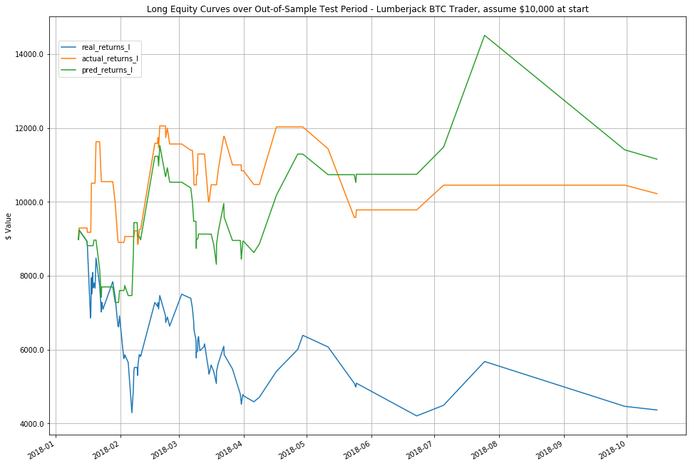

```python
#Long-only Equity Curves
ax = results[['real_returns_l', 'actual_returns_l', 'pred_returns_l']].cumsum().apply(np.exp).plot(figsize=(16, 12))

#results['pred_bin'].plot(ax=ax, secondary_y='pred_bin', style='--')
ax.get_legend().set_bbox_to_anchor((0.15, 0.95));
ax.set_ylabel("$ Value")
labels = ax.get_yticks()*10000.0
ax.set_yticklabels([str(round(float(label), 2)) for label in labels])
plt.title("Long Equity Curves over Out-of-Sample Test Period - Lumberjack BTC Trader, assume $10,000 at start")
plt.grid()
```

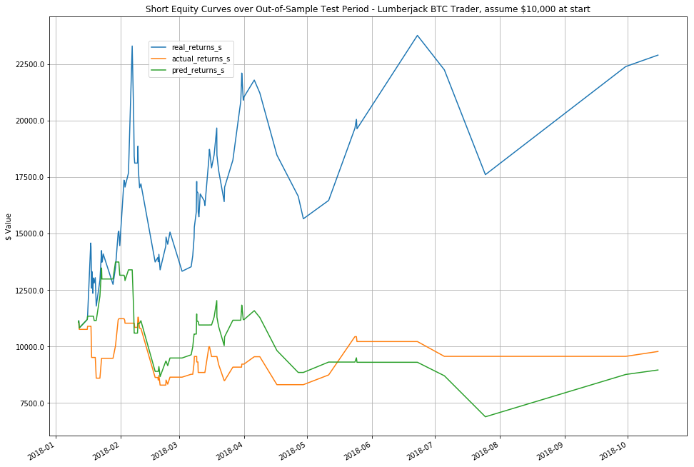

```python
#Short-only Equity Curves
ax = results[['real_returns_s', 'actual_returns_s', 'pred_returns_s']].cumsum().apply(np.exp).plot(figsize=(16, 12))

#results['pred_bin'].plot(ax=ax, secondary_y='pred_bin', style='--')
ax.get_legend().set_bbox_to_anchor((0.15, 0.95));
ax.set_ylabel("$ Value")
labels = ax.get_yticks()*10000.0
ax.set_yticklabels([str(round(float(label), 2)) for label in labels])
plt.title("Short Equity Curves over Out-of-Sample Test Period - Lumberjack BTC Trader, assume $10,000 at start")
plt.grid()
```

- Sharpe Ratio = expected returns / stdev
- Annualized return
- Factsheet - use returns / stdev / dd / ann ret / equity curve from above - completed
- Solutions Document - completed

```python
# total number of days in results (need to compute because it is not time bars)
days = (results.index[-1:] - results.index[:1]).days.values[0]
# 11.55 is the percent return for long-only over the period (see above). Let's calculate annual returns

return_per_day_pred_l = 0.1155 / days
stdev_per_day_pred_l = 0.059908

annualized_return_pred_l = ((return_per_day_pred_l + 1)**365) - 1
print("Annualized Return of Predicted Trades (Long-only):  %.2f %%" % (annualized_return_pred_l * 100))

# Annualized Standard Deviation = Standard Deviation of Returns * Square Root (250)
annualized_stdev_pred_l = stdev_per_day_pred_l * 252**0.5
print("Annualized Std Dev of Predicted Trades (Long-only):  %.5f" % (annualized_stdev_pred_l))

# Sharpe Ratio is return/volatility (assume risk-free rate negligible)
sharpe = annualized_return_pred_l / annualized_stdev_pred_l
print("Sharpe Ratio of our model (Long-only): %.2f" % sharpe)
```

```
Annualized Return of Predicted Trades (Long-only):  16.50 %
Annualized Std Dev of Predicted Trades (Long-only):  0.95101
Sharpe Ratio of our model (Long-only): 0.17
```

Save the results data as a csv.

```python
results.to_csv("../data/processed/results.csv", sep=',', encoding="utf-8")
```